# EDA n Analysis

quanggiang169

2025-05-16

# A. Data cleanning

## 1. Loading libraries

library(tidyverse) library(janitor) library(stringr) library(dplyr) library(e1071) library(knitr) library(tibble) library(kableExtra) library(ggplot2) library(gridExtra) library(ggcorrplot) library(reshape2) library(ggpubr) library(rlang) library(rstatix) library(rcompanion) library(DescTools) library(scales) library(car) library(broom) library(vip) library(ranger) library(caret)

## 2. Loading data set

```r
df_hratt <- read_csv("hr_attrition_data.csv",col_types = cols())
```

## 3. Previewing the first 10 rows of the dataset

| Age | Attrition | BusinessTravel | DailyRate | Department | DistanceFromHome | Education | EducationField | EmployeeCount | EmployeeNumber | EnvironmentSatisfaction | Gender | HourlyRate | JobInvolvement | JobLevel | JobRole | JobSatisfaction | MaritalStatus | MonthlyIncome | MonthlyRate | NumCompaniesWorked | Over18 | OverTime | PercentSalaryHike | PerformanceRating | RelationshipSatisfaction | StandardHours | StockOptionLevel | TotalWorkingYears | TrainingTimesLastYear | … |
| --- | --- | --- | --- | --- | --- | --- | --- | --- | --- | --- | --- | --- | --- | --- | --- | --- | --- | --- | --- | --- | --- | --- | --- | --- | --- | --- | --- | --- | --- | --- |
| 41 | Yes | Travel_Rarely | 1102 | Sales | 1 | 2 | Life Sciences | 1 | 1 | 2 | Female | 94 | 3 | 2 | Sales Executive | 4 | Single | 5993 | 19479 | 8 | Y | Yes | 11 | 3 | 1 | 80 | 0 | 8 | 0 | … |
| 49 | No | Travel_Frequently | 279 | Research & Development | 8 | 1 | Life Sciences | 1 | 2 | 3 | Male | 61 | 2 | 2 | Research Scientist | 2 | Married | 5130 | 24907 | 1 | Y | No | 23 | 4 | 4 | 80 | 1 | 10 | 3 | … |
| 37 | Yes | Travel_Rarely | 1373 | Research & Development | 2 | 2 | Other | 1 | 4 | 4 | Male | 92 | 2 | 1 | Laboratory Technician | 3 | Single | 2090 | 2396 | 6 | Y | Yes | 15 | 3 | 2 | 80 | 0 | 7 | 3 | … |
| 33 | No | Travel_Frequently | 1392 | Research & Development | 3 | 4 | Life Sciences | 1 | 5 | 4 | Female | 56 | 3 | 1 | Research Scientist | 3 | Married | 2909 | 23159 | 1 | Y | Yes | 11 | 3 | 3 | 80 | 0 | 8 | 3 | … |
| 27 | No | Travel_Rarely | 591 | Research & Development | 2 | 1 | Medical | 1 | 7 | 1 | Male | 40 | 3 | 1 | Laboratory Technician | 2 | Married | 3468 | 16632 | 9 | Y | No | 12 | 3 | 4 | 80 | 1 | 6 | 3 | … |
| 32 | No | Travel_Frequently | 1005 | Research & Development | 2 | 2 | Life Sciences | 1 | 8 | 4 | Male | 79 | 3 | 1 | Laboratory Technician | 4 | Single | 3068 | 11864 | 0 | Y | No | 13 | 3 | 3 | 80 | 0 | 8 | 2 | … |
| 59 | No | Travel_Rarely | 1324 | Research & Development | 3 | 3 | Medical | 1 | 10 | 3 | Female | 81 | 4 | 1 | Laboratory Technician | 1 | Married | 2670 | 9964 | 4 | Y | Yes | 20 | 4 | 1 | 80 | 3 | 12 | 3 | … |
| 30 | No | Travel_Rarely | 1358 | Research & Development | 24 | 1 | Life Sciences | 1 | 11 | 4 | Male | 67 | 3 | 1 | Laboratory Technician | 3 | Divorced | 2693 | 13335 | 1 | Y | No | 22 | 4 | 2 | 80 | 1 | 1 | 2 | … |
| 38 | No | Travel_Frequently | 216 | Research & Development | 23 | 3 | Life Sciences | 1 | 12 | 4 | Male | 44 | 2 | 3 | Manufacturing Director | 3 | Single | 9526 | 8787 | 0 | Y | No | 21 | 4 | 2 | 80 | 0 | 10 | 2 | … |
| 36 | No | Travel_Rarely | 1299 | Research & Development | 27 | 3 | Medical | 1 | 13 | 3 | Male | 94 | 3 | 2 | Healthcare Representative | 3 | Married | 5237 | 16577 | 6 | Y | No | 13 | 3 | 2 | 80 | 2 | 17 | 3 | … |

## 4. Renaming columns

I also used the `clean_names` function from the `janitor` package to standardize the column names. This helps ensure consistency by converting all column names to lowercase and replacing spaces or special characters with underscores, making the data easier to work with throughout the analysis.

## 5. Data Dictionary

The IBM HR Analytics Employee Attrition & Performance dataset is a fictional dataset created by IBM data scientists. Since not all features have descriptions, I have made interpretations of what they represent.

You can find the dataset [here](https://www.kaggle.com/pavansubhasht/ibm-hr-analytics-attrition-dataset).

| Feature Name | Data Type | Description |
| --- | --- | --- |
| Age | integer | Employee’s age in years |
| Attrition | factor | If the employee stayed or left the company (Yes ; No) |
| BusinessTravel | factor | How often the employee has business travel (Travel_Rarely ; Travel_Frequently ; Non-Travel) |
| DailyRate | integer | Employee’s daily rate in USD. |
| Department | factor | Which department the employee belongs to (Sales ; Research & Development ; Human Resources) |
| DistanceFromHome | integer | How far the employee lives from work in kilometers. |
| Education | integer | Employee’s education level (1 = Below College ; 2 = College ; 3 = Bachelor ; 4 = Master ; 5 = Doctor) |
| EducationField | factor | Employee’s education field (Life Sciences ; Medical ; Marketing ; Technical Degree, Human Resources ; Other) |
| EmployeeCount | integer | How many employees the current record represents. |
| EmployeeNumber | integer | Employee’s unique identification number |
| EnvironmentSatisfaction | integer | How satisfied the employee is with the company’s environment (1 = Low ; 2 = Medium ; 3 = High ; 4 = Very High) |
| Gender | factor | Employee’s gender (Female ; Male) |
| HourlyRate | integer | Employee’s hourly rate in USD |
| JobInvolvement | integer | How involved the employee feels with his/her job (1 = Low ; 2 = Medium ; 3 = High ; 4 = Very High) |
| JobLevel | integer | Employee’s job level (1 = Junior ; 2 = Mid ; 3 = Senior ; 4 = Manager ; 5 = Director) |
| JobRole | factor | Employee’s job role (Sales Executive ; Research Scientist ; Laboratory Technician ; Manufacturing Director ; Healthcare Representative ; Manager ; Sales Representative ; Research Director ; Human Reso… |
| JobSatisfaction | integer | How satisfied the employee feels with his/her job (1 = Low ; 2 = Medium ; 3 = High ; 4 = Very High) |
| MaritalStatus | factor | Employee’s marital status (Single ; Married ; Divorced) |
| MonthlyIncome | integer | Employee’s monthly income in USD |
| MonthlyRate | integer | Employee’s monthly rate in USD |
| NumCompaniesWorked | integer | Number of companies that the employee has already worked. |
| Over18 | factor | If the employee is over 18 years old (Yes) |
| OverTime | factor | If the employee makes overtime (Yes ; No) |
| PercentSalaryHike | integer | The percentage of the amount a salary is increased |
| PerformanceRating | integer | Employee’s performance rating (1 = Low ; 2 = Good ; 3 = Excellent ; 4 = Outstanding) |
| RelationshipSatisfaction | integer | How satisfied the employee feels with the relationship with his/her manager (1 = Low ; 2 = Medium ; 3 = High ; 4 = Very High) |
| StandardHours | integer | Employee’s standard hours of work per day |
| StockOptionLevel | integer | Employee’s stock option level (refer to: What You Should Know About Option Trading Levels) |
| TotalWorkingYears | integer | Total years that the employee has professionally worked |
| TrainingTimesLastYear | integer | Total times that the employee had a training session the last year |
| WorkLifeBalance | integer | How the employee feels about his/her work-life balance (1 = Bad ; 2 = Good ; 3 = Better ; 4 = Best) |
| YearsAtCompany | integer | Total years that the employee has worked at the company |
| YearsInCurrentRole | integer | Total years that the employee has worked in his/her current job role |
| YearsSinceLastPromotion | integer | Total years since the employee had his/her last promotion at the company |
| YearsWithCurrManager | integer | Total years that the employee has worked under his/her current manager |

## 6. Checking data dimensions

```
## Number of rows: 1470
```

```
## Number of cols: 35
```

## 7. Checking data types

```
## spc_tbl_ [1,470 × 35] (S3: spec_tbl_df/tbl_df/tbl/data.frame)
##  $ age                       : num [1:1470] 41 49 37 33 27 32 59 30 38 36 ...
##  $ attrition                 : Factor w/ 2 levels "No","Yes": 2 1 2 1 1 1 1 1 1 1 ...
##  $ business_travel           : Factor w/ 3 levels "Non-Travel","Travel_Frequently",..: 3 2 3 2 3 2 3 3 2 3 ...
##  $ daily_rate                : num [1:1470] 1102 279 1373 1392 591 ...
##  $ department                : Factor w/ 3 levels "Human Resources",..: 3 2 2 2 2 2 2 2 2 2 ...
##  $ distance_from_home        : num [1:1470] 1 8 2 3 2 2 3 24 23 27 ...
##  $ education                 : num [1:1470] 2 1 2 4 1 2 3 1 3 3 ...
##  $ education_field           : Factor w/ 6 levels "Human Resources",..: 2 2 5 2 4 2 4 2 2 4 ...
##  $ employee_count            : num [1:1470] 1 1 1 1 1 1 1 1 1 1 ...
##  $ employee_number           : num [1:1470] 1 2 4 5 7 8 10 11 12 13 ...
##  $ environment_satisfaction  : num [1:1470] 2 3 4 4 1 4 3 4 4 3 ...
##  $ gender                    : Factor w/ 2 levels "Female","Male": 1 2 2 1 2 2 1 2 2 2 ...
##  $ hourly_rate               : num [1:1470] 94 61 92 56 40 79 81 67 44 94 ...
##  $ job_involvement           : num [1:1470] 3 2 2 3 3 3 4 3 2 3 ...
##  $ job_level                 : num [1:1470] 2 2 1 1 1 1 1 1 3 2 ...
##  $ job_role                  : Factor w/ 9 levels "Healthcare Representative",..: 8 7 3 7 3 3 3 3 5 1 ...
##  $ job_satisfaction          : num [1:1470] 4 2 3 3 2 4 1 3 3 3 ...
##  $ marital_status            : Factor w/ 3 levels "Divorced","Married",..: 3 2 3 2 2 3 2 1 3 2 ...
##  $ monthly_income            : num [1:1470] 5993 5130 2090 2909 3468 ...
##  $ monthly_rate              : num [1:1470] 19479 24907 2396 23159 16632 ...
##  $ num_companies_worked      : num [1:1470] 8 1 6 1 9 0 4 1 0 6 ...
##  $ over18                    : Factor w/ 1 level "Y": 1 1 1 1 1 1 1 1 1 1 ...
##  $ over_time                 : Factor w/ 2 levels "No","Yes": 2 1 2 2 1 1 2 1 1 1 ...
##  $ percent_salary_hike       : num [1:1470] 11 23 15 11 12 13 20 22 21 13 ...
##  $ performance_rating        : num [1:1470] 3 4 3 3 3 3 4 4 4 3 ...
##  $ relationship_satisfaction : num [1:1470] 1 4 2 3 4 3 1 2 2 2 ...
##  $ standard_hours            : num [1:1470] 80 80 80 80 80 80 80 80 80 80 ...
##  $ stock_option_level        : num [1:1470] 0 1 0 0 1 0 3 1 0 2 ...
##  $ total_working_years       : num [1:1470] 8 10 7 8 6 8 12 1 10 17 ...
##  $ training_times_last_year  : num [1:1470] 0 3 3 3 3 2 3 2 2 3 ...
##  $ work_life_balance         : num [1:1470] 1 3 3 3 3 2 2 3 3 2 ...
##  $ years_at_company          : num [1:1470] 6 10 0 8 2 7 1 1 9 7 ...
##  $ years_in_current_role     : num [1:1470] 4 7 0 7 2 7 0 0 7 7 ...
##  $ years_since_last_promotion: num [1:1470] 0 1 0 3 2 3 0 0 1 7 ...
##  $ years_with_curr_manager   : num [1:1470] 5 7 0 0 2 6 0 0 8 7 ...
##  - attr(*, "spec")=
##   .. cols(
##   ..   Age = col_double(),
##   ..   Attrition = col_character(),
```

[output cut: 20 more lines]

```
##   ..   OverTime = col_character(),
##   ..   PercentSalaryHike = col_double(),
##   ..   PerformanceRating = col_double(),
##   ..   RelationshipSatisfaction = col_double(),
##   ..   StandardHours = col_double(),
##   ..   StockOptionLevel = col_double(),
##   ..   TotalWorkingYears = col_double(),
##   ..   TrainingTimesLastYear = col_double(),
##   ..   WorkLifeBalance = col_double(),
##   ..   YearsAtCompany = col_double(),
##   ..   YearsInCurrentRole = col_double(),
##   ..   YearsSinceLastPromotion = col_double(),
##   ..   YearsWithCurrManager = col_double()
##   .. )
##  - attr(*, "problems")=<externalptr>
```

```
## Count of columns by data type:
```

```
##
##  factor numeric
##       9      26
```

After checking the data types, I found that the dataset contains two main types of variables: factor, representing ordinal categorical data, and numeric, which includes both continuous data and some ordinal categorical variables encoded as numbers. This distinction is important because it guides my analysis approach. For factor variables, I will focus on frequency counts and mode-based summaries, while for numeric variables, I will apply statistical measures such as mean, median, and standard deviation. Additionally, I need to be cautious with numeric variables that actually represent ordinal categories and treat them as categorical to avoid misleading interpretations.

## 8. Checking missing data

```
##                        age                  attrition
##                          0                          0
##            business_travel                 daily_rate
##                          0                          0
##                 department         distance_from_home
##                          0                          0
##                  education            education_field
##                          0                          0
##             employee_count            employee_number
##                          0                          0
##   environment_satisfaction                     gender
##                          0                          0
##                hourly_rate            job_involvement
##                          0                          0
##                  job_level                   job_role
##                          0                          0
##           job_satisfaction             marital_status
##                          0                          0
##             monthly_income               monthly_rate
##                          0                          0
##       num_companies_worked                     over18
##                          0                          0
##                  over_time        percent_salary_hike
##                          0                          0
##         performance_rating  relationship_satisfaction
##                          0                          0
##             standard_hours         stock_option_level
##                          0                          0
##        total_working_years   training_times_last_year
##                          0                          0
##          work_life_balance           years_at_company
##                          0                          0
##      years_in_current_role years_since_last_promotion
##                          0                          0
##    years_with_curr_manager
##                          0
```

## 9. Checking duplicate data

```
## Number of duplicate rows: 0
```

## 10. Trim whitespace from character columns

I have trimmed leading and trailing whitespace characters from all character columns to ensure data consistency and prevent errors during analysis.

## 11. Feature Engineering

### 11.1. Column filtering

Random Sample from Cleaned Dataset

| age | attrition | business_travel | daily_rate | department | distance_from_home | education | education_field | environment_satisfaction | gender | hourly_rate | job_involvement | job_level | job_role | job_satisfaction | marital_status | monthly_income | monthly_rate | num_companies_worked | over_time | percent_salary_hike | performance_rating | relationship_satisfaction | stock_option_level | total_working_years | training_times_last_year | work_life_balance | years_at_company | years_in_current_role | years_since_last_promotion | … |
| --- | --- | --- | --- | --- | --- | --- | --- | --- | --- | --- | --- | --- | --- | --- | --- | --- | --- | --- | --- | --- | --- | --- | --- | --- | --- | --- | --- | --- | --- | --- |
| 34 | Yes | Travel_Rarely | 1107 | Human Resources | 9 | 4 | Technical Degree | 1 | Female | 52 | 3 | 1 | Human Resources | 3 | Married | 2742 | 3072 | 1 | No | 15 | 3 | 4 | 0 | 2 | 0 | 3 | 2 | 2 | 2 | … |

The dataset contains several columns that do not add value to the analysis:

| Column Name | Reason for Removal |
| --- | --- |
| `over18` | All employees are over 18, so this column has no variation. |
| `standard_hours` | Same standard working hours for all employees, no differentiation. |
| `employee_count` | Constant total number of employees, offers no unique insight. |
| `employee_number` | Serves as an ID, but does not contribute to analysis or prediction. |

To simplify the dataset and focus on relevant features for analyzing employee attrition, these columns are removed.

### 11.2. Label Encoding to Categorical Mapping

This step converts several numeric variables representing categorical information into factors with meaningful labels. Doing so improves clarity and interpretability when analyzing or visualizing the data.

| Variable Name | Original Codes | Recoded Labels | Description |
| --- | --- | --- | --- |
| `education` | 1, 2, 3, 4, 5 | Below College, College, Bachelor, Master, Doctor | Levels of educational attainment |
| `environment_satisfaction` | 1, 2, 3, 4 | Low, Medium, High, Very High | Satisfaction with work environment |
| `job_involvement` | 1, 2, 3, 4 | Low, Medium, High, Very High | Degree of job involvement |
| `job_level` | 1, 2, 3, 4, 5 | Junior, Mid, Senior, Manager, Director | Hierarchical job position levels |
| `job_satisfaction` | 1, 2, 3, 4 | Low, Medium, High, Very High | Satisfaction with the job |
| `performance_rating` | 1, 2, 3, 4 | Low, Good, Excellent, Outstanding | Performance evaluation ratings |
| `relationship_satisfaction` | 1, 2, 3, 4 | Low, Medium, High, Very High | Satisfaction with workplace relationships |
| `work_life_balance` | 1, 2, 3, 4 | Bad, Good, Better, Best | Quality of work-life balance |

Each variable is recoded from numeric codes into descriptive factor levels to facilitate better data understanding and analysis.

### 11.3. Checkpoint

This step saves the cleaned and processed dataset to a CSV file named `"hr_attrition_data_v2.csv"`. Saving the file ensures that the current version of the data can be easily accessed and reused for future analysis without repeating earlier processing steps.

# B. Descriptive statistics

## 1. Univariate Analysis

### 1.1. Univariate Analysis: Numerical Variables

| attributes | min | max | range | mean | median | std | skewness | kurtosis |
| --- | --- | --- | --- | --- | --- | --- | --- | --- |
| age | 18 | 60 | 42 | 3.692381e+01 | 36.0 | 9.1353735 | 0.4124432 | -0.4103776 |
| daily_rate | 102 | 1499 | 1397 | 8.024857e+02 | 802.0 | 403.5090999 | -0.0035114 | -1.2062539 |
| distance_from_home | 1 | 29 | 28 | 9.192517e+00 | 7.0 | 8.1068644 | 0.9561635 | -0.2319182 |
| hourly_rate | 30 | 100 | 70 | 6.589116e+01 | 66.0 | 20.3294276 | -0.0322450 | -1.1988648 |
| monthly_income | 1009 | 19999 | 18990 | 6.502931e+03 | 4919.0 | 4707.9567831 | 1.3670224 | 0.9923007 |
| monthly_rate | 2094 | 26999 | 24905 | 1.431310e+04 | 14235.5 | 7117.7860441 | 0.0185399 | -1.2173343 |
| num_companies_worked | 0 | 9 | 9 | 2.693197e+00 | 2.0 | 2.4980090 | 1.0243772 | 0.0020117 |
| percent_salary_hike | 11 | 25 | 14 | 1.520952e+01 | 14.0 | 3.6599377 | 0.8194530 | -0.3073229 |
| stock_option_level | 0 | 3 | 3 | 7.938776e-01 | 1.0 | 0.8520767 | 0.9670037 | 0.3547475 |
| total_working_years | 0 | 40 | 40 | 1.127959e+01 | 10.0 | 7.7807817 | 1.1148929 | 0.9057509 |
| training_times_last_year | 0 | 6 | 6 | 2.799320e+00 | 3.0 | 1.2892706 | 0.5519959 | 0.4844864 |
| years_at_company | 0 | 40 | 40 | 7.008163e+00 | 5.0 | 6.1265252 | 1.7609300 | 3.9086474 |
| years_in_current_role | 0 | 18 | 18 | 4.229252e+00 | 3.0 | 3.6231370 | 0.9154918 | 0.4669978 |
| years_since_last_promotion | 0 | 15 | 15 | 2.187755e+00 | 1.0 | 3.2224303 | 1.9802422 | 3.5873464 |
| years_with_curr_manager | 0 | 17 | 17 | 4.123129e+00 | 3.0 | 3.5681361 | 0.8317508 | 0.1620914 |

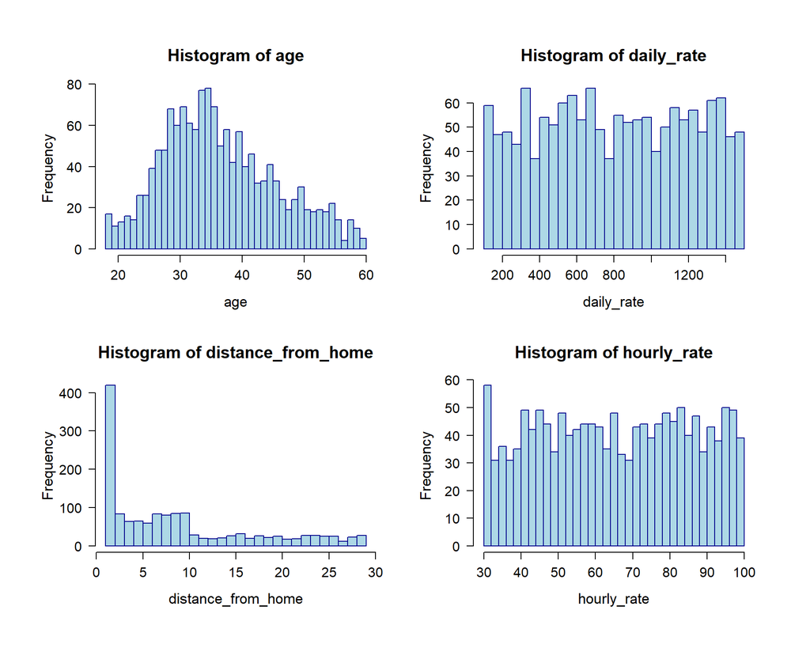

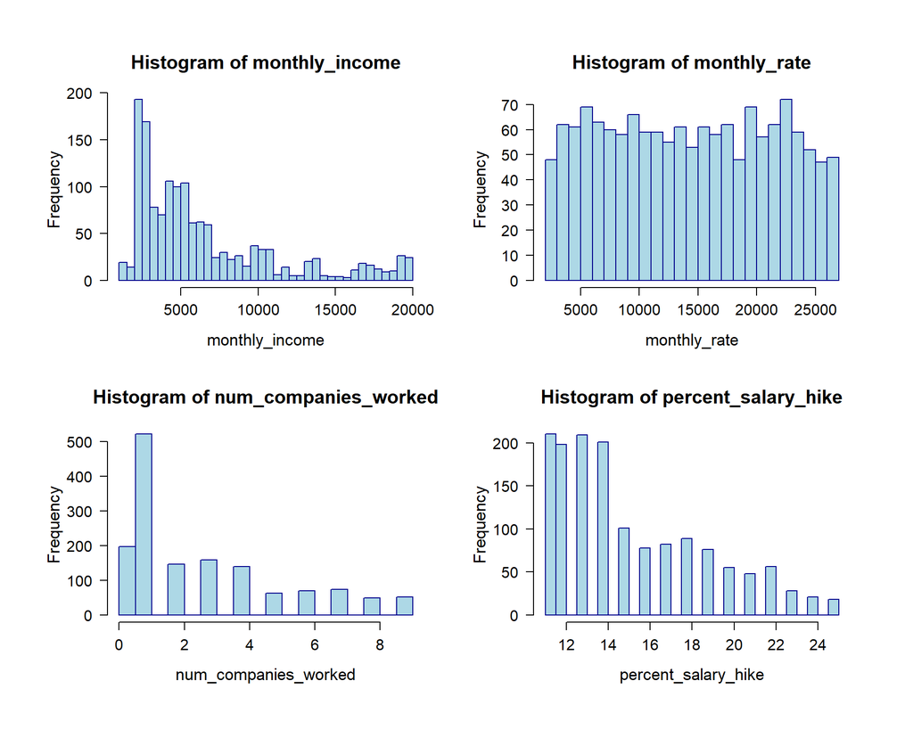

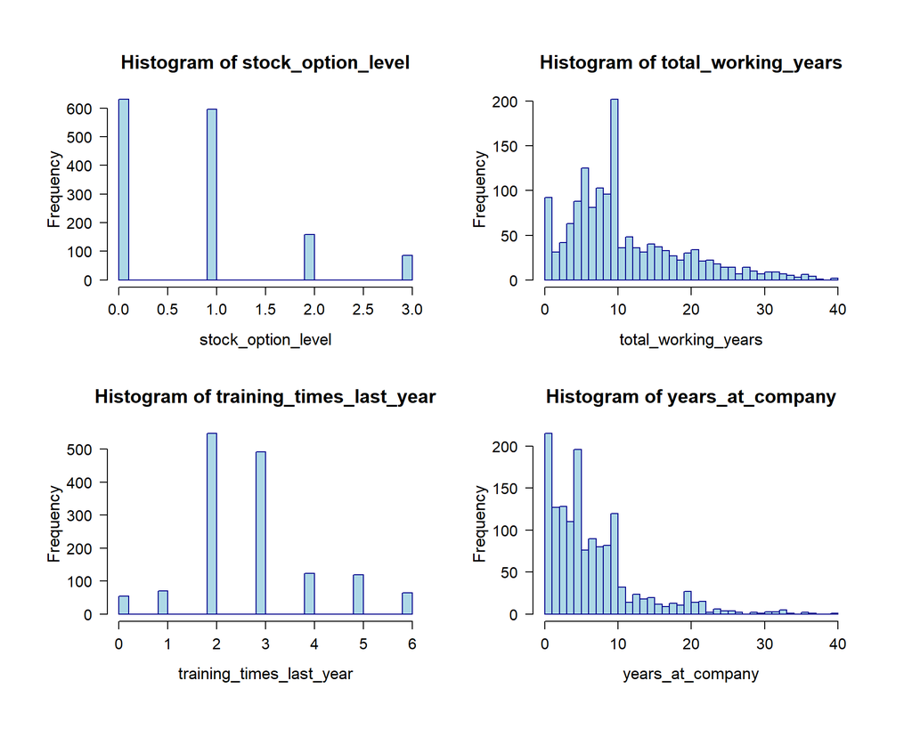

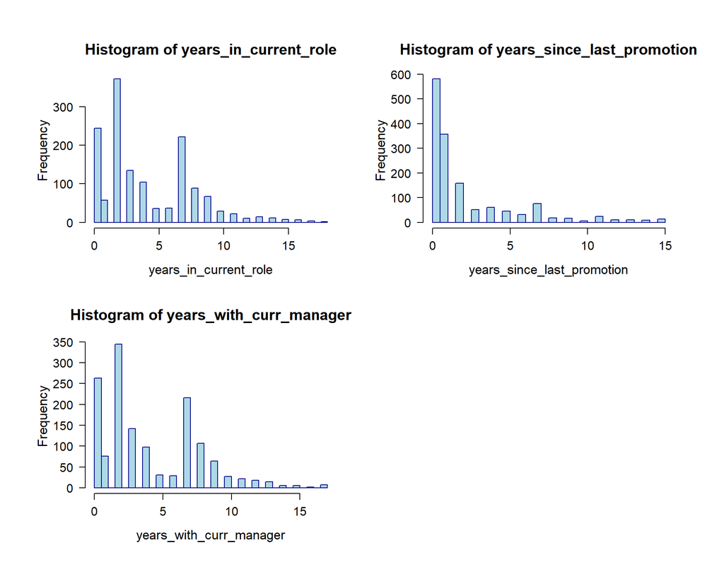

| **Key Findings** | **Explanation** |
| --- | --- |
| **Age**: Approximately symmetric distribution with slight right skewness (skewness ~0.41), median age is 36 years | Most employees are middle-aged; age distribution is fairly balanced without strong skew. |
| **Daily Rate & Hourly Rate**: Nearly symmetric distributions with very small skewness (close to 0) | Compensation rates per day and hour are fairly evenly distributed without extreme low or high values. |
| **Distance from Home**: Right skewed (skewness ~0.96), indicating many employees live close to the workplace and fewer live farther away | Majority of employees live near the office; a small number reside at greater distances. |
| **Monthly Income**: Noticeably right skewed (skewness ~1.37) with positive kurtosis (~1), indicating a long tail on the high-income side | Many employees earn low to medium income, with a few earning significantly higher incomes. |
| **Number of Companies Worked**: Right skewed (skewness ~1.02), suggesting most employees have worked at few companies | Majority of employees have limited job-hopping experience; few have worked at multiple companies. |
| **Percent Salary Hike**: Mild right skew (skewness ~0.82) | Most salary increases are moderate, with a few instances of higher raises. |
| **Years at Company** and **Years Since Last Promotion**: Strong right skewness (skewness ~1.76 and ~1.98) with high kurtosis (3.9 and 3.6 respectively) | Many employees are relatively new or have been promoted recently; a smaller group has long tenure and longer duration since last promotion. |
| **Other variables (stock option level, training times last year, years in current role, years with current manager)**: Slight to moderate right skew | These variables mostly concentrate at lower to medium values, with fewer high-value cases. |

**Summary**

- Time-related variables (tenure, promotion history, salary hike) show right-skewed distributions, reflecting that most employees are clustered at lower to medium values, with a small group exhibiting higher values.
- Monthly income and distance from home also show right skewness with long right tails.
- Compensation rates (daily and hourly) are more symmetrically distributed.

### 1.2. Univariate Analysis: Categorical Variables

#### 1.2.1. Check Unique Value Counts for Categorical Attributes

Summary of Unique Values in Categorical Variables

|  | no.unique.values | unique.values |
| --- | --- | --- |
| attrition | 2 | Yes, No |
| business_travel | 3 | Travel_Rarely, Travel_Frequently, Non-Travel |
| department | 3 | Sales, Research & Development, Human Resources |
| education | 5 | College, Below College, Master, Bachelor, Doctor |
| education_field | 6 | Life Sciences, Other, Medical, Marketing, Technical Degree, Human Resources |
| environment_satisfaction | 4 | Medium, High, Very High, Low |
| gender | 2 | Female, Male |
| job_involvement | 4 | High, Medium, Very High, Low |
| job_level | 5 | Mid, Junior, Senior, Manager, Director |
| job_role | 9 | Sales Executive, Research Scientist, Laboratory Technician, Manufacturing Director, Healthcare Representative, Manager, Sales Representative, Research Director, Human Resources |
| job_satisfaction | 4 | Very High, Medium, High, Low |
| marital_status | 3 | Single, Married, Divorced |
| over_time | 2 | Yes, No |
| performance_rating | 2 | Excellent, Outstanding |
| relationship_satisfaction | 4 | Low, Very High, Medium, High |
| work_life_balance | 4 | Bad, Better, Good, Best |

#### 1.2.2 Frequency Distribution of Categorical Variables

This section provides a descriptive overview of the categorical variables in the dataset to establish a foundational understanding of the employee profile and organizational characteristics.

### Frequency Table for attrition

Distribution of attrition

| Category | Count | Percentage (%) |
| --- | --- | --- |
| No | 1233 | 83.88 |
| Yes | 237 | 16.12 |

### Frequency Table for business_travel

Distribution of business_travel

| Category | Count | Percentage (%) |
| --- | --- | --- |
| Non-Travel | 150 | 10.20 |
| Travel_Frequently | 277 | 18.84 |
| Travel_Rarely | 1043 | 70.95 |

### Frequency Table for department

Distribution of department

| Category | Count | Percentage (%) |
| --- | --- | --- |
| Human Resources | 63 | 4.29 |
| Research & Development | 961 | 65.37 |
| Sales | 446 | 30.34 |

### Frequency Table for education

Distribution of education

| Category | Count | Percentage (%) |
| --- | --- | --- |
| Bachelor | 572 | 38.91 |
| Below College | 170 | 11.56 |
| College | 282 | 19.18 |
| Doctor | 48 | 3.27 |
| Master | 398 | 27.07 |

### Frequency Table for education_field

Distribution of education_field

| Category | Count | Percentage (%) |
| --- | --- | --- |
| Human Resources | 27 | 1.84 |
| Life Sciences | 606 | 41.22 |
| Marketing | 159 | 10.82 |
| Medical | 464 | 31.56 |
| Other | 82 | 5.58 |
| Technical Degree | 132 | 8.98 |

### Frequency Table for environment_satisfaction

Distribution of environment_satisfaction

| Category | Count | Percentage (%) |
| --- | --- | --- |
| High | 453 | 30.82 |
| Low | 284 | 19.32 |
| Medium | 287 | 19.52 |
| Very High | 446 | 30.34 |

### Frequency Table for gender

Distribution of gender

| Category | Count | Percentage (%) |
| --- | --- | --- |
| Female | 588 | 40 |
| Male | 882 | 60 |

### Frequency Table for job_involvement

Distribution of job_involvement

| Category | Count | Percentage (%) |
| --- | --- | --- |
| High | 868 | 59.05 |
| Low | 83 | 5.65 |
| Medium | 375 | 25.51 |
| Very High | 144 | 9.80 |

### Frequency Table for job_level

Distribution of job_level

| Category | Count | Percentage (%) |
| --- | --- | --- |
| Director | 69 | 4.69 |
| Junior | 543 | 36.94 |
| Manager | 106 | 7.21 |
| Mid | 534 | 36.33 |
| Senior | 218 | 14.83 |

### Frequency Table for job_role

Distribution of job_role

| Category | Count | Percentage (%) |
| --- | --- | --- |
| Healthcare Representative | 131 | 8.91 |
| Human Resources | 52 | 3.54 |
| Laboratory Technician | 259 | 17.62 |
| Manager | 102 | 6.94 |
| Manufacturing Director | 145 | 9.86 |
| Research Director | 80 | 5.44 |
| Research Scientist | 292 | 19.86 |
| Sales Executive | 326 | 22.18 |
| Sales Representative | 83 | 5.65 |

### Frequency Table for job_satisfaction

Distribution of job_satisfaction

| Category | Count | Percentage (%) |
| --- | --- | --- |
| High | 442 | 30.07 |
| Low | 289 | 19.66 |
| Medium | 280 | 19.05 |
| Very High | 459 | 31.22 |

### Frequency Table for marital_status

Distribution of marital_status

| Category | Count | Percentage (%) |
| --- | --- | --- |
| Divorced | 327 | 22.24 |
| Married | 673 | 45.78 |
| Single | 470 | 31.97 |

### Frequency Table for over_time

Distribution of over_time

| Category | Count | Percentage (%) |
| --- | --- | --- |
| No | 1054 | 71.7 |
| Yes | 416 | 28.3 |

### Frequency Table for performance_rating

Distribution of performance_rating

| Category | Count | Percentage (%) |
| --- | --- | --- |
| Excellent | 1244 | 84.63 |
| Outstanding | 226 | 15.37 |

### Frequency Table for relationship_satisfaction

Distribution of relationship_satisfaction

| Category | Count | Percentage (%) |
| --- | --- | --- |
| High | 459 | 31.22 |
| Low | 276 | 18.78 |
| Medium | 303 | 20.61 |
| Very High | 432 | 29.39 |

### Frequency Table for work_life_balance

Distribution of work_life_balance

| Category | Count | Percentage (%) |
| --- | --- | --- |
| Bad | 80 | 5.44 |
| Best | 153 | 10.41 |
| Better | 893 | 60.75 |
| Good | 344 | 23.40 |

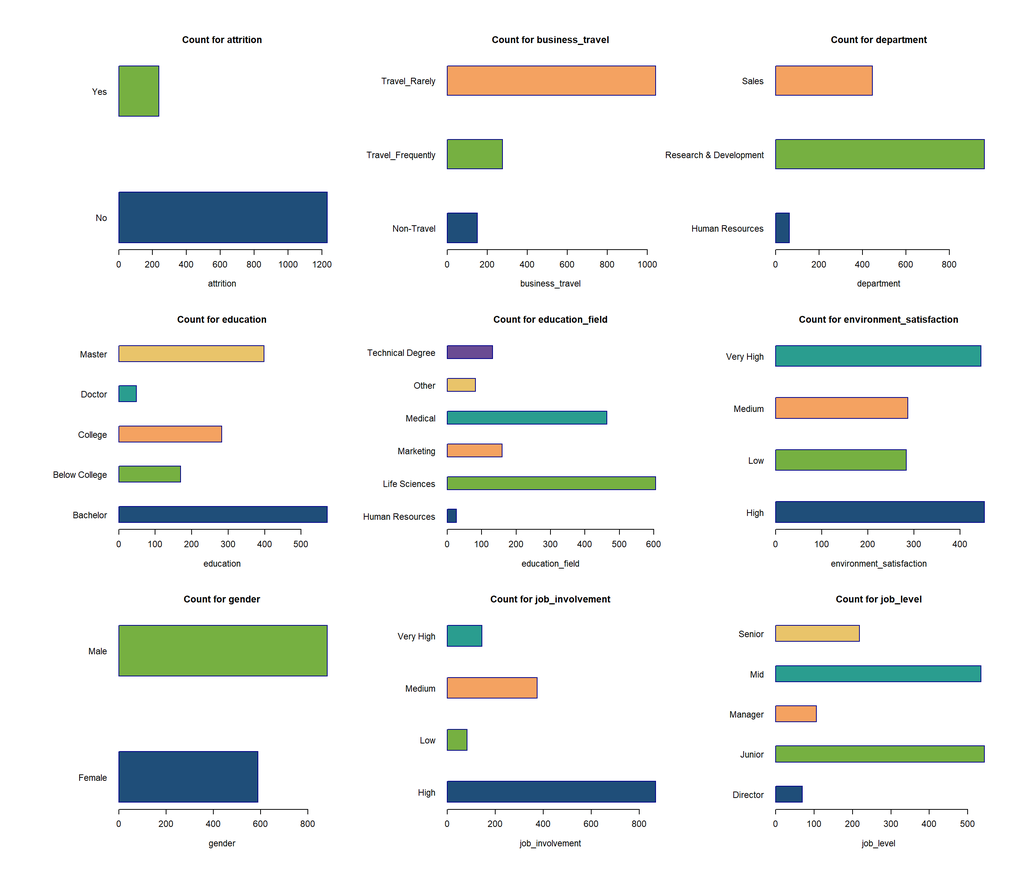

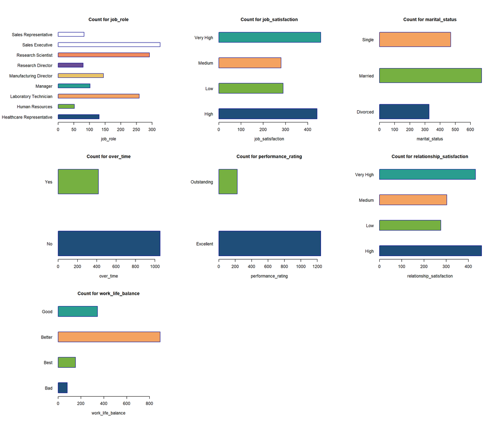

## 2. Coss-variable connections

### 2.1. Correlation between numerical attributes

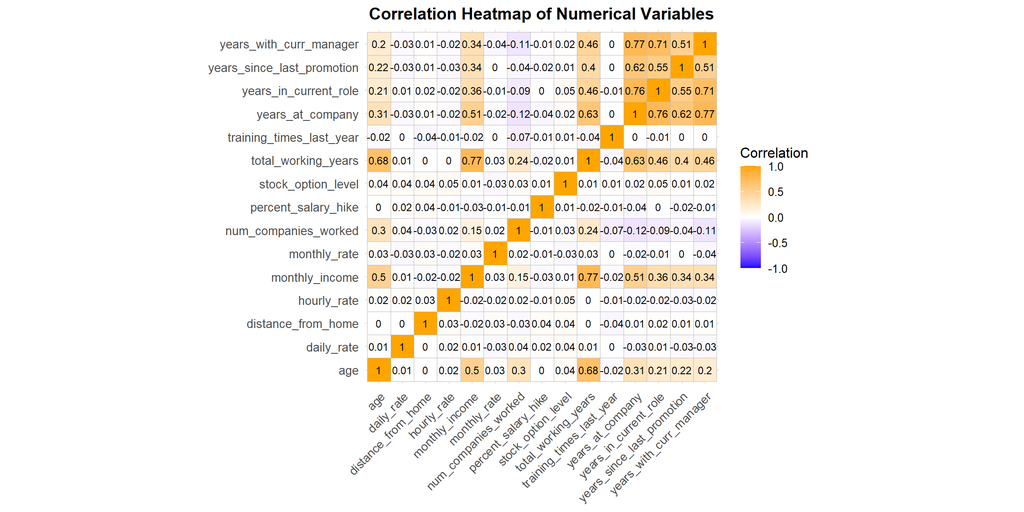

### 2.2. Associations between categorical attributes

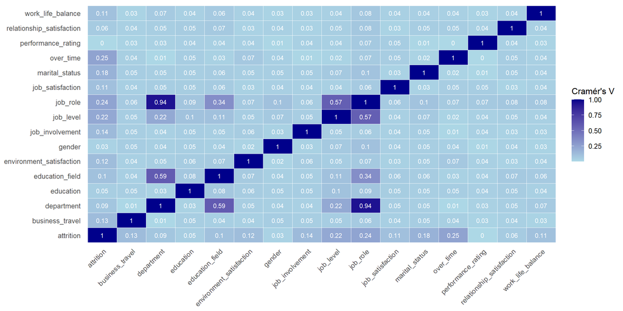

### 2.3. Interaction Between Numeric and Categorical Variables

Statistically Significant Factor-Numeric Relationships (Kruskal-Wallis, p < 0.05)

| Factor_Variable | Numeric_Variable | P_Value |
| --- | --- | --- |
| attrition | age | 0.00000 |
| attrition | monthly_income | 0.00000 |
| attrition | stock_option_level | 0.00000 |
| attrition | total_working_years | 0.00000 |
| attrition | years_at_company | 0.00000 |
| attrition | years_in_current_role | 0.00000 |
| attrition | years_with_curr_manager | 0.00000 |
| department | monthly_income | 0.00000 |
| education | age | 0.00000 |
| education | num_companies_worked | 0.00000 |
| education | total_working_years | 0.00000 |
| job_level | age | 0.00000 |
| job_level | monthly_income | 0.00000 |
| job_level | num_companies_worked | 0.00000 |
| job_level | total_working_years | 0.00000 |
| job_level | years_at_company | 0.00000 |
| job_level | years_in_current_role | 0.00000 |
| job_level | years_since_last_promotion | 0.00000 |
| job_level | years_with_curr_manager | 0.00000 |
| job_role | age | 0.00000 |
| job_role | monthly_income | 0.00000 |
| job_role | num_companies_worked | 0.00000 |
| job_role | total_working_years | 0.00000 |
| job_role | years_at_company | 0.00000 |
| job_role | years_in_current_role | 0.00000 |
| job_role | years_since_last_promotion | 0.00000 |
| job_role | years_with_curr_manager | 0.00000 |
| marital_status | stock_option_level | 0.00000 |
| performance_rating | percent_salary_hike | 0.00000 |
| education | monthly_income | 0.00002 |
| marital_status | age | 0.00008 |
| education_field | monthly_income | 0.00015 |
| marital_status | total_working_years | 0.00057 |
| marital_status | monthly_income | 0.00219 |
| attrition | distance_from_home | 0.00239 |
| marital_status | years_at_company | 0.00523 |
| marital_status | years_in_current_role | 0.00523 |
| over_time | training_times_last_year | 0.00669 |
| relationship_satisfaction | years_since_last_promotion | 0.00886 |
| marital_status | daily_rate | 0.01335 |
| job_level | distance_from_home | 0.01584 |
| attrition | daily_rate | 0.02900 |
| marital_status | years_since_last_promotion | 0.02928 |
| job_satisfaction | hourly_rate | 0.03977 |
| attrition | years_since_last_promotion | 0.04117 |
| attrition | training_times_last_year | 0.04729 |

# C. Inferential Analysis

## 1. Bivariate Analysis with Attrition

In this step, I explore how each selected feature relates to employee attrition. Using visualizations, I compare the attrition rate across different groups or ranges of each variable. This helps me identify patterns or potential drivers that may point to HR policies needing improvement.

### 1.1. Compensation & Rewards

#### 1.1.1. Monthly Income

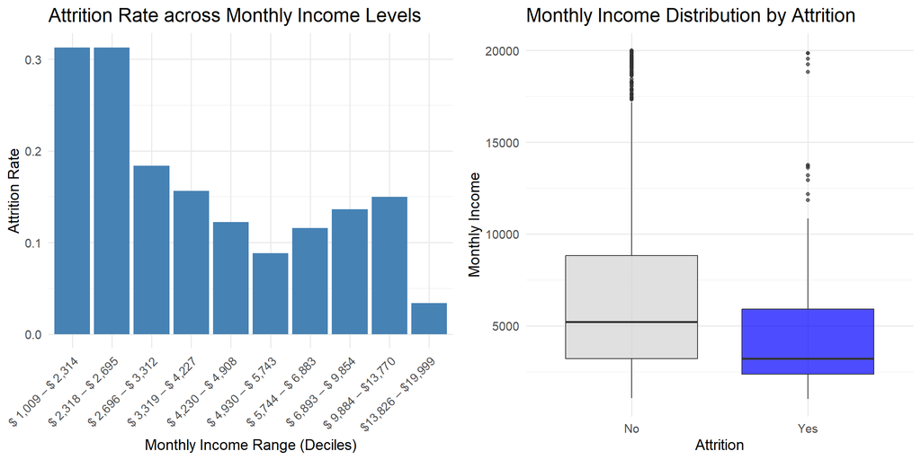

The variable Monthly Income shows a clear relationship with attrition when analyzed through two charts. A bar chart dividing income into 10 deciles indicates that attrition rates are significantly high among the lowest income groups (decile 1 and 2), exceeding 0.3. However, at decile 3, the rate drops sharply to below 0.2—marking a notable turning point. From decile 4 to decile 6, the attrition rate continues to decline gradually, reaching below 0.1. From decile 7 onward, the rate fluctuates slightly, increasing again at decile 9 (around 0.15) before falling dramatically to under 0.05 in decile 10, the highest income group. This suggests that the relationship between income and attrition is not linear, but may be influenced by certain income thresholds that affect employee behavior. The boxplot further supports this insight, showing that the group of employees who left had noticeably lower median, Q1, and Q3 income levels than those who stayed, reflecting a clear trend of higher attrition among low-income employees.

From this analysis, the following hypotheses can be proposed:

- **H0**: The minimum income of 2696 does not affect employees’ likelihood of attrition.
- **H1**: The minimum income of 2696 helps reduce employees’ likelihood of attrition. **TRUE**

Contingency Table: Income Group vs Attrition

|  | No | Yes |
| --- | --- | --- |
| < 2696 | 202 | 92 |
| >= 2696 | 1031 | 145 |

```
##
##  Pearson's Chi-squared test with Yates' continuity correction
##
## data:  table_income_attrition
## X-squared = 61.145, df = 1, p-value = 5.301e-15
```

The test results show a Chi-squared statistic of 61.145 with 1 degree of freedom, and a p-value of 5.30 × 10⁻¹⁵, which is significantly less than the 0.05 significance level. This allows us to reject the null hypothesis (H₀), providing statistical evidence that income level is associated with attrition rate.

Specifically, employees earning less than 2,696 have a substantially higher attrition rate (31.3%) compared to those earning 2,696 or more (12.3%). This supports the alternative hypothesis (H₁) that a minimum income level of 2,696 contributes to reducing attrition risk.

#### 1.1.2. Percent Salary Hike

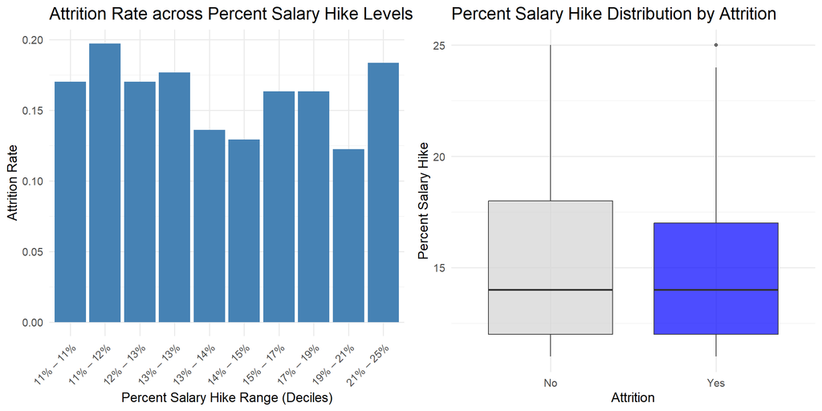

The variable Percent Salary Hike shows no clear relationship with attrition when examined through two visualizations. In the bar chart, as Percent Salary Hike increases, the attrition rate fluctuates slightly within a range from below 0.125 to nearly 0.2, without exhibiting a consistent upward or downward trend. This suggests that the annual percentage increase in salary does not serve as a strong predictor of employee attrition. The boxplot reinforces this observation, as the median and Q1 values for both the attrition and non-attrition groups are nearly identical, with only a marginally higher Q3 value for the group that stayed. However, this difference is not substantial enough to indicate a meaningful disparity. Overall, the distribution of salary hike percentages between the two groups does not provide strong evidence that higher raises are effective in improving retention.

#### 1.1.3. Stock Option Level

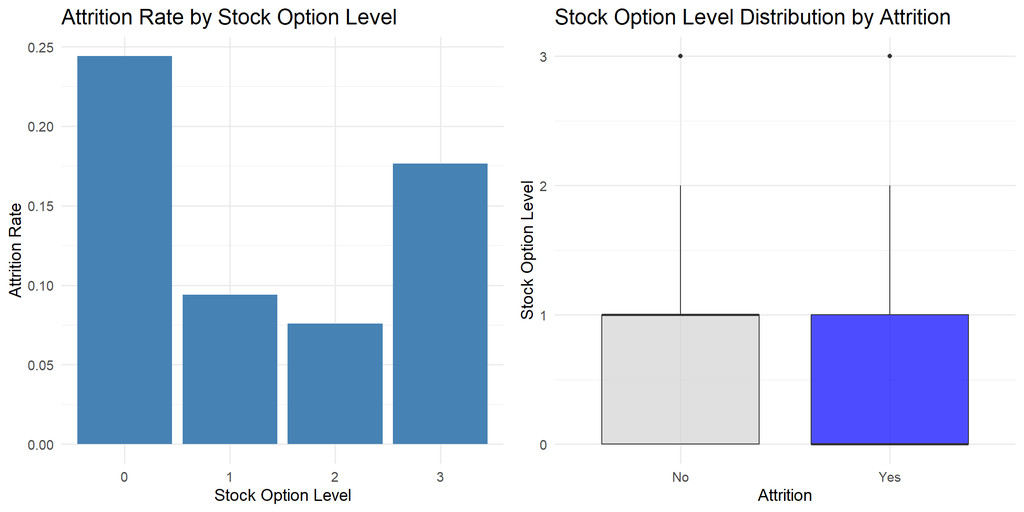

The Stock Option Level variable shows a clear relationship between the level of stock options and the attrition rate. The bar chart on the left indicates that employees without stock options (Stock Option Level = 0) have the highest attrition rate, approximately 0.24. When the stock option level increases to 1, the attrition rate drops sharply to around 0.1, suggesting that having stock options may help reduce attrition. However, at higher levels such as 2 and 3, the attrition rates fluctuate mildly, about 0.075 and 0.175 respectively, not following a strictly decreasing trend.

The boxplot also shows that the median Stock Option Level for employees who did not leave (Attrition = No) is 1, higher than the median of 0 for those who left (Attrition = Yes), while the Q1 and Q3 values for both groups are relatively similar.

From this, we can propose the following hypotheses:

- **H0**:Attrition rate is the same between employees with no stock option (level 0) and employees with at least one stock option (level ≥1).
- **H1**: Employees with no stock option level have higher attrition rate than those with stock option (one-sided test).**TRUE**

Attrition Summary by Stock Option Group

| Stock Option Group | Total Employees | Attrition = Yes | Attrition = No | Attrition Rate |
| --- | --- | --- | --- | --- |
| Has Stock Option | 839 | 83 | 756 | 0.099 |
| No Stock Option | 631 | 154 | 477 | 0.244 |

```
##
##  Pearson's Chi-squared test with Yates' continuity correction
##
## data:  table_stock_attrition
## X-squared = 55.025, df = 1, p-value = 1.19e-13
```

The Chi-squared test results show a statistic of 55.025 with 1 degree of freedom and a p-value of 1.19 × 10⁻¹³, which is significantly less than the 0.05 significance level. Therefore, we reject the null hypothesis (H₀), indicating strong statistical evidence to support the alternative hypothesis (H₁): Employees without stock options have a higher attrition rate than those with stock options.

In practice, the attrition rate among employees without stock options is 24.4%, which is approximately 2.5 times higher than that of employees with stock options (9.9%).

### 1.2 Career Development & Advancement

#### 1.2.1. Job Level

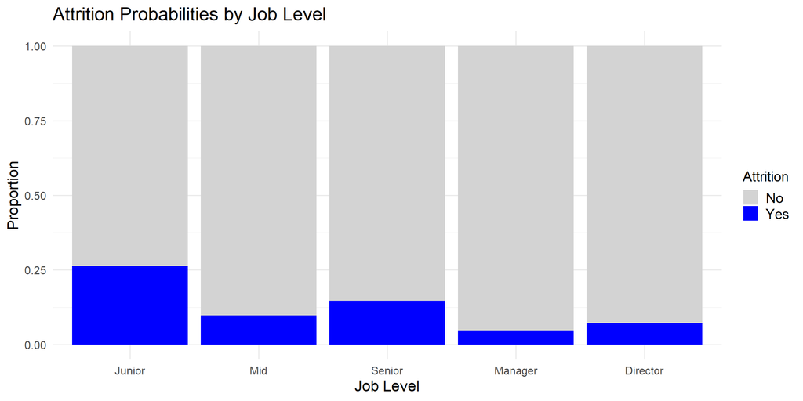

This trend may reflect differences in job stability, compensation, or motivation across job levels within the organization.

From these observations, we can propose the following hypotheses:

- **H0**: The attrition rate of the Junior group is not higher than the attrition rate of the other groups.
- **H1**: The attrition rate of the Junior group is higher than the attrition rate of the other groups.**TRUE**

Attrition Summary: Junior vs Others

| Job Level Group | Total Employees | Attrition = Yes | Attrition = No | Attrition Rate |
| --- | --- | --- | --- | --- |
| Junior | 543 | 143 | 400 | 0.263 |
| Others | 927 | 94 | 833 | 0.101 |

```
##
##  Pearson's Chi-squared test with Yates' continuity correction
##
## data:  table_binary_job_attrition
## X-squared = 65.219, df = 1, p-value = 6.701e-16
```

The one-sided Chi-squared test results show a statistic of X-squared = 65.219 with 1 degree of freedom and a p-value of 6.701 × 10⁻¹⁶, which is much smaller than the significance level of 0.05. Therefore, we reject the null hypothesis (H₀) and have sufficient statistical evidence to confirm that the Junior group has a significantly higher attrition rate compared to other groups.

Specifically, the attrition rate in the Junior group is 26.3%, while in the other groups it is only 10.1%, meaning the attrition rate in the Junior group is nearly 2.6 times higher.

#### 1.2.2. Years Since Last Promotion

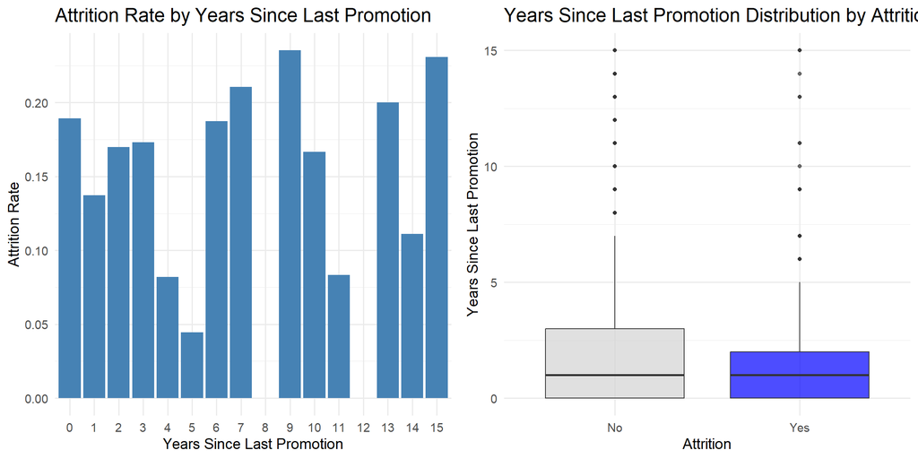

The chart reveals a complex fluctuation in attrition rates based on the number of years since an employee’s last promotion. During the first 3 years after promotion (0–3 years), attrition rates remain elevated — ranging from 13% to over 17%. This suggests that the early post-promotion period does not guarantee retention. Instead, it may involve two subgroups: those who are disengaged due to unmet expectations and those who feel their promotion has not led to meaningful change or support.

This period (0–3 years) can be considered a “fragile engagement phase,” where employees may still be assessing the real value of their advancement. Without proper career guidance, enriched responsibilities, or recognition beyond the title change, some employees may start seeking external opportunities even shortly after being promoted.

However, starting from year 6, attrition begins to rise again sharply, with noticeable spikes in years 7, 9, and 15 — often exceeding 20%. This pattern suggests a potential “career stagnation zone,” where the absence of new development signals or promotion opportunities may drive employees to leave.

These findings suggest a psychological lifecycle after promotion: early uncertainty (0–3 years), mid-stage stability (4–5 years), and late-stage disengagement (6+ years).

From this, we can propose the following hypotheses:

- **H0**: There is no significant difference in the number of years since the last promotion between employees who left the company and those who stayed.
- **H1**: There is a significant difference in the number of years since the last promotion between employees who left the company and those who stayed.**TRUE**

Attrition by Years Since Last Promotion

| Promotion Group | Total Employees | Attrition = Yes | Attrition = No | Attrition Rate |
| --- | --- | --- | --- | --- |
| 0–3 years | 1149 | 195 | 954 | 0.170 |
| 4–5 years | 106 | 7 | 99 | 0.066 |
| 6+ years | 215 | 35 | 180 | 0.163 |

```
##
##  Pearson's Chi-squared test
##
## data:  table_promotion_attrition
## X-squared = 7.7181, df = 2, p-value = 0.02109
```

The Pearson’s Chi-squared test yielded a p-value of 0.02109, which is less than the significance level of 0.05. Therefore, we reject the null hypothesis. This suggests a statistically significant relationship between Years Since Last Promotion and Attrition — meaning the number of years since an employee’s last promotion is associated with their likelihood of leaving the company. Further analysis on specific subgroups could help identify the most sensitive periods, enabling the development of targeted retention strategies.

#### 1.2.3. Training Times Last Year

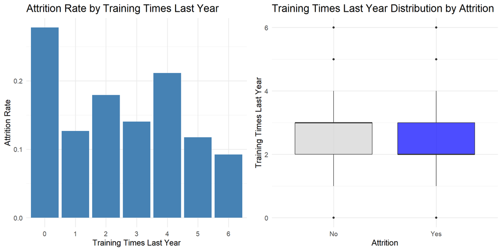

Preliminary analysis suggests that employees who did not participate in any training sessions during the year had a higher attrition rate compared to those who attended at least some training. Meanwhile, employees who participated in 1 to 6 training sessions tended to be more likely to stay, although the differences between these groups were not entirely consistent. This may indicate that training participation is related to employee engagement, though the relationship is not clearly linear.

From this, we can propose the following hypotheses:

- **H0**: The attrition rate of employees who received no training (0 times) is not significantly different from that of employees who received training (≥1 time).
- **H1**:* Employees who received no training have a significantly higher attrition rate.**TRUE**

Attrition Summary by Training Group

| Training Group | Total Employees | Attrition = Yes | Attrition = No | Attrition Rate |
| --- | --- | --- | --- | --- |
| Had Training | 1416 | 222 | 1194 | 0.157 |
| No Training | 54 | 15 | 39 | 0.278 |

```
##
##  Pearson's Chi-squared test with Yates' continuity correction
##
## data:  table_training_attrition
## X-squared = 4.7722, df = 1, p-value = 0.02892
```

The Chi-squared test with Yates’ correction shows a statistic of X-squared = 4.7722, with 1 degree of freedom and a p-value = 0.02892, which is less than the significance level of 0.05. Therefore, we reject the null hypothesis (H₀) and have sufficient statistical evidence to conclude that employees who have not received training have a significantly higher attrition rate compared to those who have received training.

Specifically, the attrition rate among untrained employees is 27.8%, while the attrition rate among trained employees is 15.7%, indicating that the untrained group has nearly double the risk of attrition.

#### 1.2.3. Years In Current Role

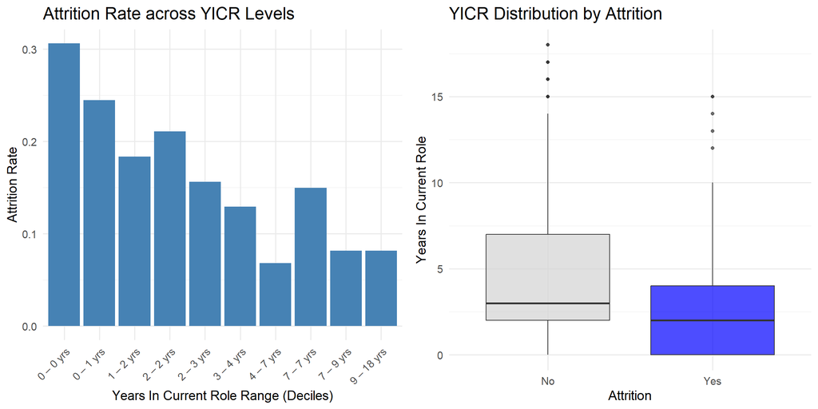

The variable Years in Current Role reflects how long employees have held their current position and shows a relatively clear relationship with attrition. The bar chart indicates a general downward trend in attrition rates as tenure in the current role increases, though some minor fluctuations exist across deciles. Overall, the early deciles—representing employees who are new to their role or recently transferred—exhibit significantly higher attrition rates compared to the later deciles. This suggests that the initial phase in a new role is a critical period with a higher risk of turnover.

The boxplot reinforces this pattern: the Q1, median, and Q3 values for the attrition group (Yes) are all lower than those for the non-attrition group (No), indicating that most employees who leave the company tend to have shorter tenure in their current roles.

Based on these observations, several hypotheses can be proposed:

- **H0**: There is no relationship in the attrition rate with respect to the number of years in the current role.
- **H1**: The longer the Years In Current Role, the lower the attrition rate.**TRUE**

```
##
##  Cochran-Armitage test for trend
##
## data:  table_years_attr
## Z = 5.2477, dim = 3, p-value = 7.699e-08
## alternative hypothesis: one.sided
```

The test results show a very small p-value (p = 7.699e-08), well below the common significance threshold (0.05), along with a positive Z-score (Z = 5.2477). This provides strong evidence to reject the null hypothesis and accept the alternative. In other words, there is statistical evidence indicating that the longer employees stay in their current role, the lower their likelihood of attrition. This finding may reflect increasing stability and job satisfaction over time in a given role. It suggests that supporting employees to grow within their current roles may be an effective strategy for improving retention.

### 1.3. Work-Life Balance & Flexibility

#### 1.3.1. OverTime

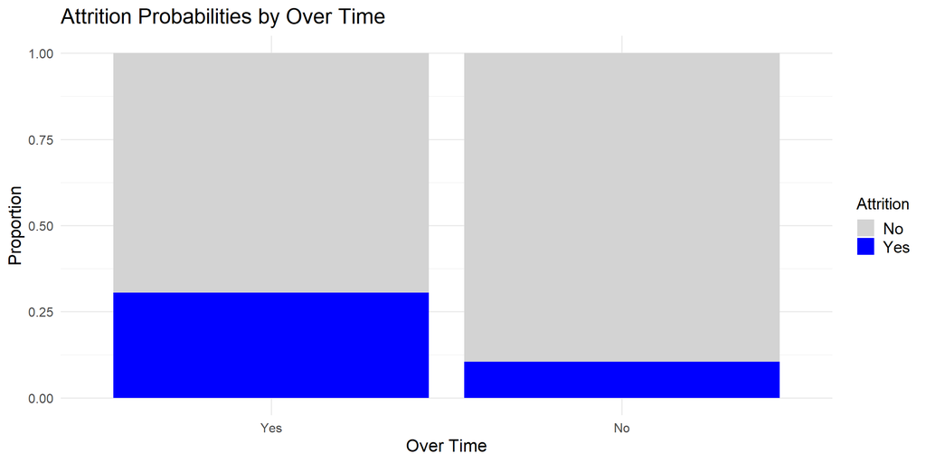

The variable Overtime reveals a striking difference in attrition rates between employees who work overtime and those who do not. The bar chart indicates that employees working overtime (“Yes”) have an attrition rate nearly three times higher than those who do not (“No”) — approximately 0.30 compared to just 0.10. This suggests that overtime may be a significant contributing factor to employee turnover, potentially due to job-related stress, poor work-life balance, or feelings of being overworked.

Based on these observations, the following hypotheses can be proposed:

- **H0**: Employees who work overtime do not have a higher attrition rate compared to those who do not work overtime.
- **H0**: Employees who work overtime have a higher attrition rate compared to those who do not work overtime. **TRUE**

Attrition by OverTime Status

| OverTime | Total | Attrition = Yes | Attrition = No | Attrition Rate |
| --- | --- | --- | --- | --- |
| Yes | 416 | 127 | 289 | 0.305 |
| No | 1054 | 110 | 944 | 0.104 |

```
##
##  Pearson's Chi-squared test with Yates' continuity correction
##
## data:  table_ot_attr
## X-squared = 87.564, df = 1, p-value < 2.2e-16
```

The Chi-squared test with Yates’ correction shows a statistic of X-squared = 87.564, with 1 degree of freedom and a p-value < 2.2e-16, which is much smaller than the significance level of 0.05. Therefore, we reject the null hypothesis (H₀) and have sufficient evidence to conclude that employees who work overtime have a significantly higher attrition rate compared to those who do not.

Specifically, the attrition rate among overtime employees is 30.5%, while the attrition rate among non-overtime employees is only 10.4%, indicating that the attrition rate in the overtime group is nearly three times higher than the other group.

#### 1.3.2. Distance From Home

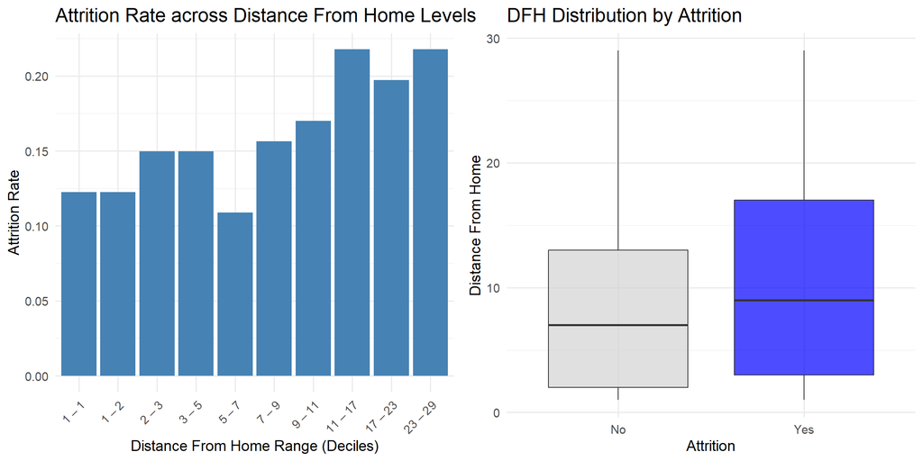

The variable Distance From Home exhibits a positive correlation with attrition rate. The bar chart clearly shows that as the commuting distance increases, so does the likelihood of employee attrition. Employees living closer to the workplace (lower deciles) have significantly lower attrition rates compared to those living farther away (higher deciles). This suggests that long commuting distances may contribute to fatigue, reduced job satisfaction, or disruption of work-life balance. The boxplot further supports this pattern, with Q1, median, and Q3 values for the attrition group (Yes) all higher than those of the non-attrition group (No), indicating that employees who leave tend to live farther from the office.

Based on these findings, the following hypotheses can be proposed:

- **H0**: Distance from home has no effect on employee attrition.
- **H1**: Employees who live farther from the workplace are more likely to leave.**TRUE**

```
##
## Call:
## glm(formula = attrition_binary ~ distance_from_home, family = binomial,
##     data = df_hratt)
##
## Coefficients:
##                     Estimate Std. Error z value Pr(>|z|)
## (Intercept)        -1.890051   0.111382 -16.969  < 2e-16 ***
## distance_from_home  0.024710   0.008312   2.973  0.00295 **
## ---
## Signif. codes:  0 '***' 0.001 '**' 0.01 '*' 0.05 '.' 0.1 ' ' 1
##
## (Dispersion parameter for binomial family taken to be 1)
##
##     Null deviance: 1298.6  on 1469  degrees of freedom
## Residual deviance: 1290.0  on 1468  degrees of freedom
## AIC: 1294
##
## Number of Fisher Scoring iterations: 4
```

The logistic regression model shows that the variable `distance_from_home` has a positive and statistically significant effect on employee attrition (estimated coefficient = 0.0247, p-value = 0.00295 < 0.01). This indicates that as the distance from home to the workplace increases, the probability of an employee leaving the company also increases.

Although the coefficient is not large, its significance at the 1% level highlights it as a potential risk factor in employee retention strategies. It is especially relevant for employees who commute long distances daily.

#### 1.3.3. Business Travel

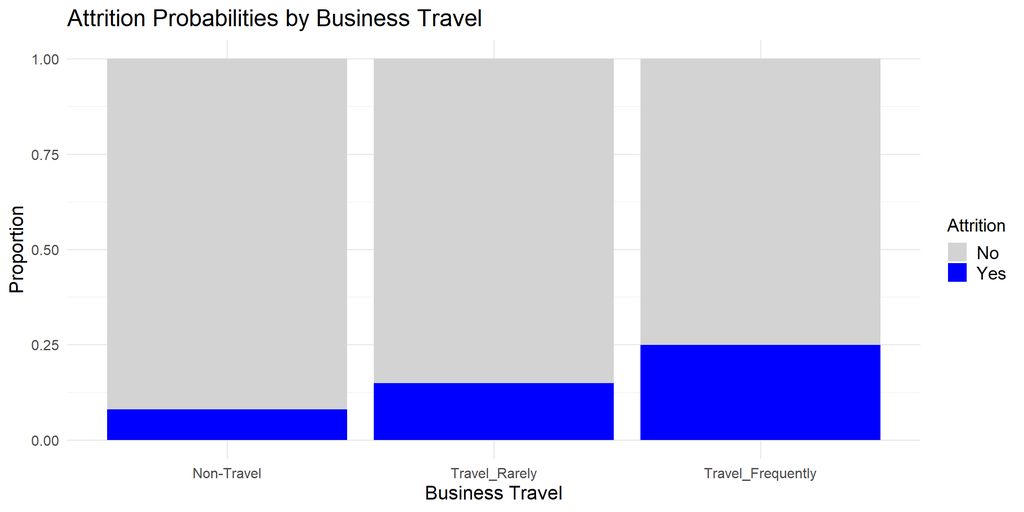

Based on these observations, several hypotheses can be proposed:

- **H0**: There is no relationship between business travel frequency (`business_travel`) and employee attrition rate.
- **H1**: The higher the frequency of business travel, the higher the employee attrition rate.**TRUE**

```
##
## Call:
## glm(formula = attrition_binary ~ business_travel_ord, family = binomial,
##     data = df_hratt)
##
## Coefficients:
##                       Estimate Std. Error z value Pr(>|z|)
## (Intercept)           -1.42071    0.08191 -17.344  < 2e-16 ***
## business_travel_ord.L  0.44870    0.11584   3.873 0.000107 ***
## ---
## Signif. codes:  0 '***' 0.001 '**' 0.01 '*' 0.05 '.' 0.1 ' ' 1
##
## (Dispersion parameter for binomial family taken to be 1)
##
##     Null deviance: 1205.4  on 1319  degrees of freedom
## Residual deviance: 1191.2  on 1318  degrees of freedom
##   (150 observations deleted due to missingness)
## AIC: 1195.2
##
## Number of Fisher Scoring iterations: 4
```

The logistic regression results show that the variable `business_travel` (frequency of business travel) has a positive and highly statistically significant effect on the likelihood of employee attrition (estimate = 0.4487, p-value = 0.000107 < 0.001). This means that as the frequency of business travel increases, the probability of employees leaving the company also increases.

#### 1.3.4. Work Life Balance

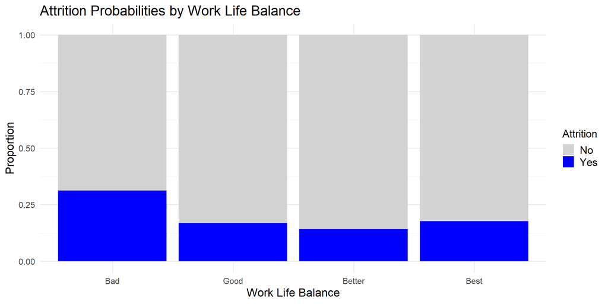

The Work Life Balance variable demonstrates a significant influence on employee attrition. The bar chart reveals that employees who rated their work-life balance as “Bad” have the highest attrition rate — around 0.30. In contrast, those who rated it as “Good”, “Better”, or “Best” exhibit substantially lower attrition rates, hovering around 0.15. This indicates that employees’ perception of support in balancing work and personal life is a critical factor in retention.

Based on these findings, several hypotheses can be proposed:

- **H0**: The attrition rate of employees with work_life_balance = “Bad” is not higher than other groups.
- **H1**:* Employees with work_life_balance = “Bad” have a higher attrition rate.**TRUE**

Attrition Rate by Work Life Balance Group (Bad vs Others)

| Work Life Balance Group | Total Employees | Attrition = Yes | Attrition = No | Attrition Rate |
| --- | --- | --- | --- | --- |
| Bad | 80 | 25 | 55 | 0.312 |
| Others | 1390 | 212 | 1178 | 0.153 |

```
##
##  Pearson's Chi-squared test with Yates' continuity correction
##
## data:  table_wlb_attrition
## X-squared = 13.158, df = 1, p-value = 0.0002862
```

The test results show that employees who rate their work-life balance as “Bad” have a significantly higher attrition rate compared to other groups (31.2% vs. 15.3%). The Chi-squared test (X² = 13.158, p-value = 0.0002862) indicates that this difference is statistically significant, thus rejecting the null hypothesis.

### 1.4. Performance Management

#### 1.4.1. Performance Rating

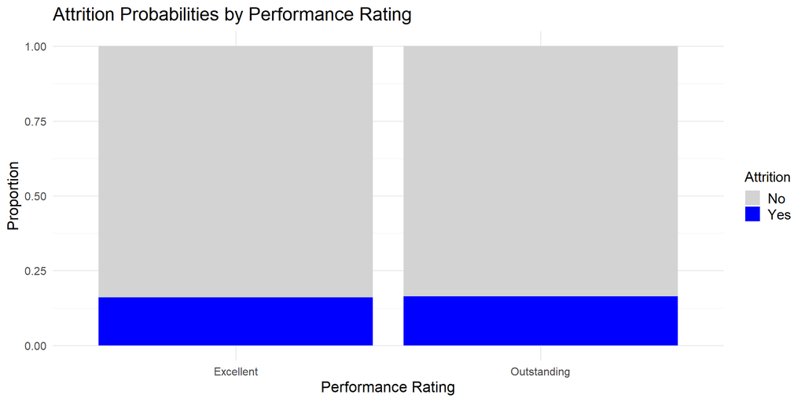

The Performance Rating variable does not show a clear difference in attrition rates between groups. The chart illustrates that both primary groups — “Excellent” and “Outstanding” — have similar attrition rates, around 0.15, with negligible variation. This suggests that current performance evaluations may not be a strong factor influencing employee attrition.

Based on this, we can draw the following conclusions:

- The Performance Rating may not accurately reflect actual job performance or may not be effectively used for differentiating between employees.
- The variable might suffer from skewed distribution (e.g., most employees falling into just one or two categories), reducing its analytical value.

#### 1.4.2. Job Involvement

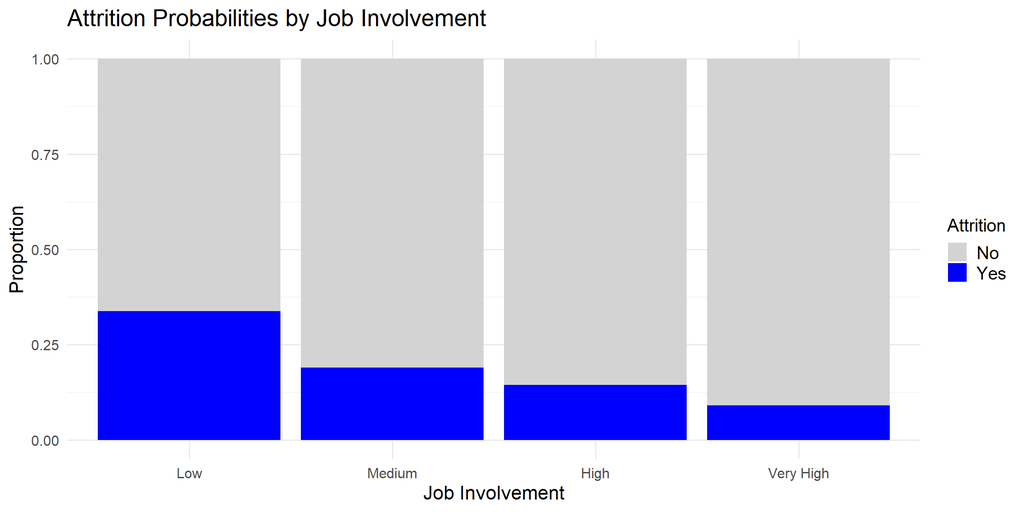

The Job Involvement variable shows a clear relationship with attrition rates. Employees with low job involvement have the highest attrition rate, around 0.30, whereas those with very high involvement show a much lower rate, approximately 0.10. This downward trend suggests that job engagement and commitment play a critical role in employee retention.

From this observation, we can derive the following hypotheses:

- **H0**: There is no relationship between job involvement level and employee attrition.
- **H1**: Lower levels of job involvement are associated with higher attrition rates.**TRUE**

Attrition Summary by Job Involvement Level

| Job Involvement | Total | Attrition = Yes | Attrition = No | Attrition Rate |
| --- | --- | --- | --- | --- |
| Low | 83 | 28 | 55 | 0.337 |
| Medium | 375 | 71 | 304 | 0.189 |
| High | 868 | 125 | 743 | 0.144 |
| Very High | 144 | 13 | 131 | 0.090 |

```
##
##  Pearson's Chi-squared test
##
## data:  table_involvement_attrition
## X-squared = 28.492, df = 3, p-value = 2.863e-06
```

The results of the Chi-squared test indicate that the difference in attrition rates across job involvement levels is statistically significant, with a p-value = 2.86e-06, which is well below the 0.001 significance threshold. This allows us to reject the null hypothesis (H₀) and accept the alternative hypothesis (H₁): Employees with lower levels of job involvement tend to have a higher likelihood of attrition.

#### 1.4.3. Job Satisfaction

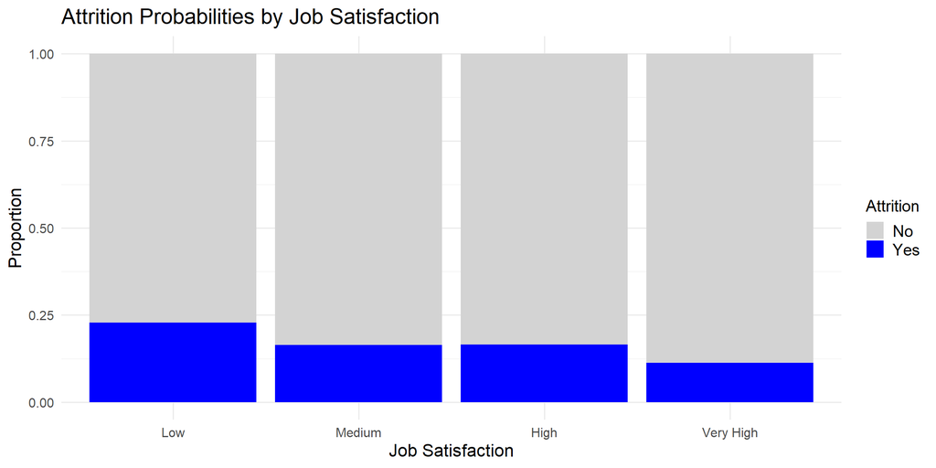

The Job Satisfaction variable shows a clear inverse correlation with attrition: as job satisfaction increases, the attrition rate decreases. Specifically, employees with the lowest level of satisfaction (“Low”) exhibit the highest attrition rate, around 0.23, while those with “Very High” satisfaction have a significantly lower rate, below 0.125. This trend highlights a strong link between job satisfaction and employees’ likelihood to stay.

Based on these findings, we can propose the following hypotheses:

- **H0**: There is no relationship between job satisfaction level and employee attrition.
- **H1**: Lower levels of job satisfaction are associated with higher attrition rates.**TRUE**

Attrition Summary by Job Satisfaction Level

| Job Satisfaction | Total Employees | Attrition = Yes | Attrition = No | Attrition Rate |
| --- | --- | --- | --- | --- |
| Low | 289 | 66 | 223 | 0.228 |
| Medium | 280 | 46 | 234 | 0.164 |
| High | 442 | 73 | 369 | 0.165 |
| Very High | 459 | 52 | 407 | 0.113 |

```
##
##  Pearson's Chi-squared test
##
## data:  table_satisfaction_attrition
## X-squared = 17.505, df = 3, p-value = 0.0005563
```

The Chi-squared test yielded a p-value of 0.0005563, which is less than the conventional significance level of 0.05. This indicates that the differences in attrition rates among different satisfaction levels are statistically significant. Therefore, we reject the null hypothesis (H₀) and accept the alternative hypothesis (H₁): Lower job satisfaction is associated with a higher likelihood of attrition.

### 1.5. Employee Engagement & Support

#### 1.5.1. Relationship Satisfaction

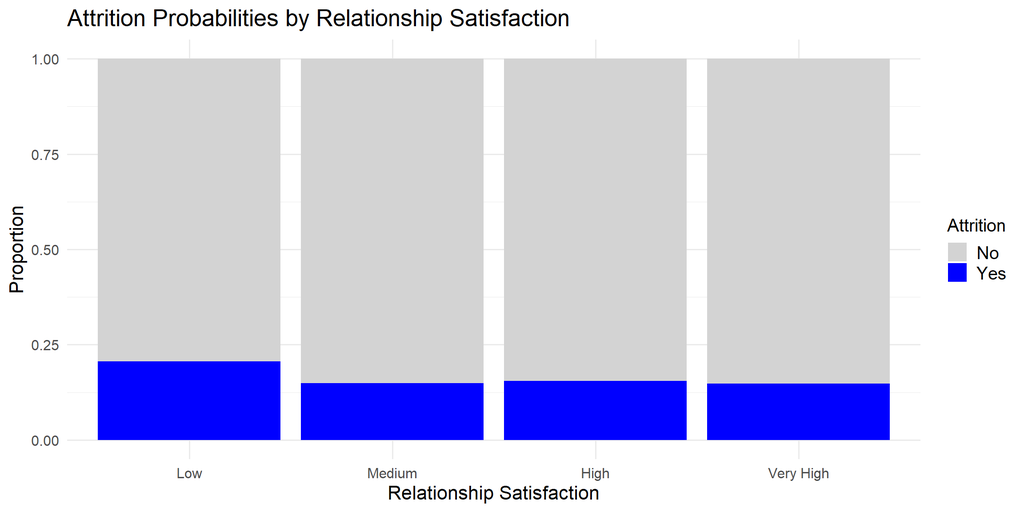

Based on this observation, the following hypotheses can be proposed:

- **H0**: There is no association between relationship satisfaction level and employee attrition.
- **H1**: Employees with “Low” relationship satisfaction have a higher likelihood of attrition compared to those with higher satisfaction levels.**TRUE**

Attrition Summary by Relationship Satisfaction Group

| Relationship Satisfaction | Total | Attrition = Yes | Attrition = No | Attrition Rate |
| --- | --- | --- | --- | --- |
| Low | 276 | 57 | 219 | 0.207 |
| Others | 1194 | 180 | 1014 | 0.151 |

```
##
##  Pearson's Chi-squared test with Yates' continuity correction
##
## data:  table_relationship
## X-squared = 4.7516, df = 1, p-value = 0.02927
```

The Chi-squared test with Yates’ continuity correction yielded a p-value of 0.029, which is less than the conventional significance level of 0.05. Therefore, we reject the null hypothesis (H₀) and accept the alternative hypothesis (H₁): there is a statistically significant association between relationship satisfaction and attrition.

Specifically, employees with low relationship satisfaction tend to have a higher attrition rate compared to those with higher levels of satisfaction.

#### 1.5.2. Environment Satisfaction

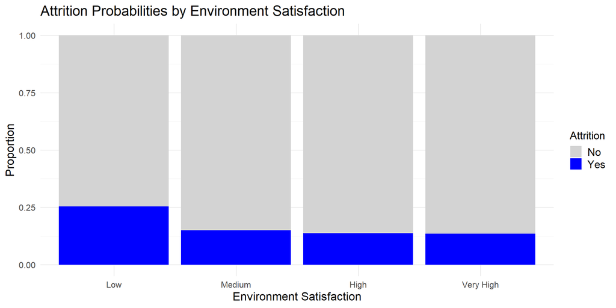

The Environment Satisfaction variable demonstrates a significant relationship between employees’ satisfaction with their work environment and attrition rates. Specifically, employees reporting low satisfaction have the highest attrition rate, around 0.25, whereas those in Medium, High, and Very High satisfaction groups show a marked decrease, stabilizing around 0.125. This indicates that the work environment—including physical conditions, space, safety, and overall working conditions—plays a crucial role in employee retention.

From this observation, the following hypotheses can be made:

- **H0**: There is no association between environment satisfaction level and employee attrition.
- **H1**: Employees with “Low” environment satisfaction have a higher likelihood of attrition compared to those with higher satisfaction levels.**TRUE**

Attrition Summary by Environment Satisfaction

| Environment Satisfaction | Total Employees | Attrition = Yes | Attrition = No | Attrition Rate |
| --- | --- | --- | --- | --- |
| Low | 284 | 72 | 212 | 0.254 |
| Others | 1186 | 165 | 1021 | 0.139 |

```
##
##  Pearson's Chi-squared test with Yates' continuity correction
##
## data:  table_environment
## X-squared = 21.336, df = 1, p-value = 3.854e-06
```

The Chi-squared test with Yates’ continuity correction returned a p-value of 3.854e-06, which is significantly below the standard significance level of 0.05. This result allows us to reject the null hypothesis (H₀) and accept the alternative hypothesis (H₁): there is a statistically significant association between environment satisfaction and employee attrition.

Specifically, employees who are dissatisfied with their work environment tend to have a higher attrition rate compared to those with higher levels of satisfaction.

### 1.6. Recruitment & Onboarding

#### 1.6.1. Num Companies Worked

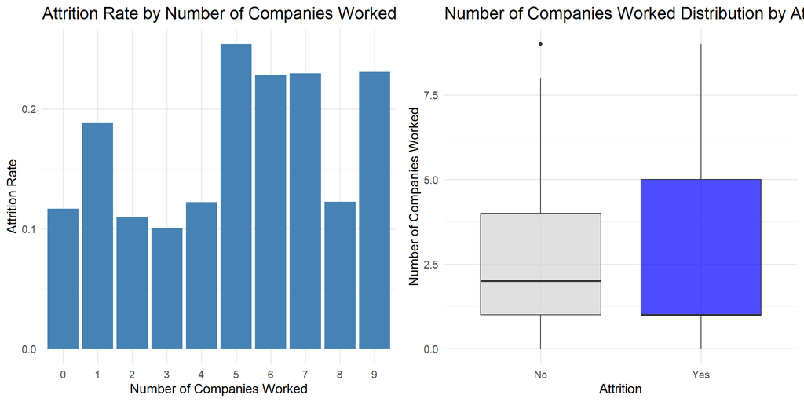

The analysis of the chart shows that employees who have never worked at another company (Num Companies Worked = 0) have a relatively low average attrition rate, indicating relative stability within this group. In contrast, employees who have worked at one previous company exhibit a significantly higher attrition rate, suggesting that those with one prior job change may be less stable or still seeking better opportunities.

Employees with experience at 2 to 4 companies show relatively low and stable attrition rates, possibly reflecting a group with moderate experience who balance engagement and career development well.

Meanwhile, the group with 5 or more previous companies shows relatively high and variable attrition rates, indicating a tendency for frequent job changes and potentially greater difficulty in retention. This could be due to personal traits favoring change or an ongoing search for a better long-term fit.

The boxplot analysis further reveals that the lower quartile (Q1) of both attrition and retention groups is similar, but the median attrition group is lower while the upper quartile (Q3) is higher than that of the retention group, indicating greater diversity in the work history of those who leave.

From this observation, the following hypotheses can be made:

- **H0**: There is no significant difference in attrition rates across groups based on the number of companies previously worked for (0, 1, 2–4, 5+).
- **H1**: There is a significant difference in attrition rates across groups based on the number of companies previously worked for.**TRUE**

Attrition Summary by Number of Companies Worked

| Company Group | Total | Attrition = Yes | Attrition = No | Attrition Rate |
| --- | --- | --- | --- | --- |
| 0 Companies | 197 | 23 | 174 | 0.117 |
| 1 Company | 521 | 98 | 423 | 0.188 |
| 2–4 Companies | 444 | 49 | 395 | 0.110 |
| 5+ Companies | 308 | 67 | 241 | 0.218 |

```
##
##  Pearson's Chi-squared test
##
## data:  table_companies_attrition
## X-squared = 21.38, df = 3, p-value = 8.779e-05
```

The result of the Chi-squared test (p-value = 0.00008779 < 0.05) indicates a statistically significant difference in attrition rates across employee groups based on the number of companies they have previously worked for. Therefore, we reject the null hypothesis (H₀) and accept the alternative hypothesis (H₁): the number of previous employers is associated with an employee’s likelihood of leaving the current organization.

This finding suggests that individuals who have switched jobs frequently (5 or more companies) may have developed a pattern of not committing to one organization for an extended period. They might be more accustomed to frequent changes in their work environment, which could make them more likely to leave the current company when challenges arise or new opportunities appear.

On the other hand, employees who have worked for only one company before may also exhibit high attrition rates. This could stem from a lack of experience in adapting to new work environments. They may struggle to adjust to differences in organizational culture, management style, or operational processes, leading to feelings of misalignment or disappointment compared to initial expectations. Additionally, transitioning from a stable environment to a new one could result in cultural shock or change-related stress, making it easier for them to consider leaving the company.

In contrast, employees with experience working for 2–4 companies may have gained sufficient exposure to different environments, helping them better understand their career expectations, develop adaptability to change, and select organizations that align with their preferences. As a result, they tend to be more stable and demonstrate greater commitment to their current organization.

#### 1.6.2. Years At Company

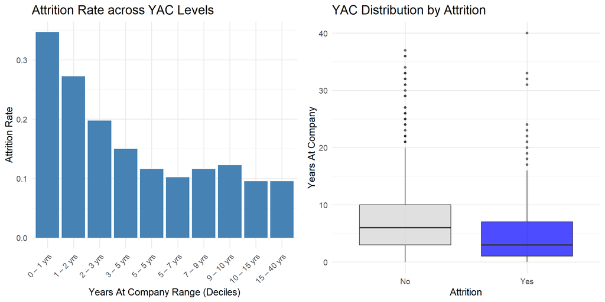

Based on this analysis, the following hypotheses can be proposed:

- **H0**:There is no relationship in the attrition rate with respect to the number of years worked at the company
- **H1**:The longer the Years At Company, the lower the attrition rate.**FALSE**

Summary of Years at Company by Attrition Group

| Attrition | Total | Median Years at Company | Mean Years at Company |
| --- | --- | --- | --- |
| No | 1233 | 6 | 7.37 |
| Yes | 237 | 3 | 5.13 |

```
##
##  Wilcoxon rank sum test with continuity correction
##
## data:  years_at_company by attrition
## W = 189639, p-value = 1
## alternative hypothesis: true location shift is less than 0
```

The analysis results indicate that there is no statistically significant relationship between the number of years an employee has worked at the company and their likelihood of leaving. Although employees who left the company had a lower median tenure (3 years compared to 6 years) and a lower mean tenure (5.13 years compared to 7.37 years), the Wilcoxon test produced a p-value of 1, which is considerably greater than the significance threshold of 0.05.

This means there is insufficient evidence to reject the null hypothesis (H₀). In other words, it cannot be concluded that longer tenure at the company reduces the likelihood of attrition.

- **H0**: There is no difference in attrition rates between employees with 0–3 years of tenure and those with ≥4 years at the company.
- **H1**: Employees with 0–3 years of tenure have a higher attrition rate compared to those with 4 or more years.**TRUE**

Attrition Summary by Years at Company Group

| Years at Company Group | Total Employees | Attrition = Yes | Attrition = No | Attrition Rate |
| --- | --- | --- | --- | --- |
| 0-3 years | 470 | 122 | 348 | 0.260 |
| Over 3 years | 1000 | 115 | 885 | 0.115 |

```
##
##  Pearson's Chi-squared test with Yates' continuity correction
##
## data:  table_years_attrition
## X-squared = 48.355, df = 1, p-value = 3.557e-12
```

The Chi-squared test results indicate a statistically significant relationship between the number of years worked at the company and the attrition rate (p-value < 0.001). Specifically, employees who have worked at the company for 0–3 years have a substantially higher attrition rate (26%) compared to those who have stayed for more than 3 years (11.5%).

This reflects a common organizational reality: the risk of attrition is typically higher during the early stages of employment, when employees have not yet formed strong attachments to the company, are still evaluating the work environment, or have not had their initial expectations met. In contrast, those who remain beyond three years have generally overcome early challenges and tend to be more stable.

This result also helps explain why the earlier Wilcoxon test did not detect a clear relationship when analyzing continuous years of service — but when categorizing the data into specific groups, the differences become evident and statistically significant.

#### 1.6.3. Years With Current Manager

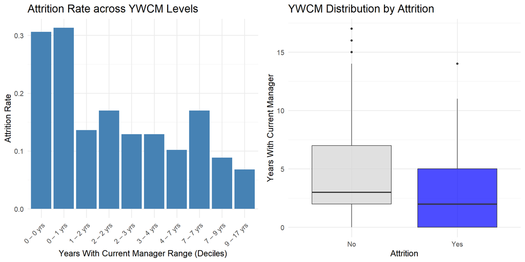

The boxplot supports this trend: the Q1, median, and Q3 values for the attrition group (Yes) are all lower than those for the non-attrition group (No), suggesting that employees who leave tend to have had shorter working relationships with their current managers.

From these findings, we can propose the following hypotheses:

- **H0**: There is no difference in attrition rates between employees who have worked with their current manager for 0–1 year and those who have worked for ≥2 years.
- **H1**: Employees who have worked with their current manager for 0–1 year have a higher attrition rate compared to those with ≥2 years.**TRUE**

Attrition Summary by Manager Tenure Group

| Manager Tenure Group | Total Employees | Attrition = Yes | Attrition = No | Attrition Rate |
| --- | --- | --- | --- | --- |
| 0-1 years | 339 | 96 | 243 | 0.283 |
| 2+ years | 1131 | 141 | 990 | 0.125 |

```
##
##  Pearson's Chi-squared test with Yates' continuity correction
##
## data:  table_mgr_attrition
## X-squared = 47.299, df = 1, p-value = 6.094e-12
```

The Chi-squared test results indicate a statistically significant difference in attrition rates between two groups of employees based on the length of time working with their direct manager (p-value < 0.001). Specifically, employees who have worked with their current manager for only 0–1 year show a much higher attrition rate (28.3%) compared to those who have worked with their manager for 2 years or more (12.5%).

This suggests that the length of the employee-manager relationship may play an important role in employee retention. Newly formed relationships with managers may not yet have had sufficient time to build trust, support, and mutual understanding.

## 2. In-depth Feature Exploration

### 2.1. Compensation & Rewards

### 2.1.1. Monthly Income (Identifying Employee Segments Sensitive to Income and Attrition)

- **H0**: The minimum salary (2696) does not affect the attrition rate in any employee group categorized by job level and years of service.
- **H1**: The minimum salary (2696) affects the attrition rate in at least one employee group categorized by job level and years of service. **TRUE**

Attrition vs. Income by Subgroup

|  | Group | p_value | odds_ratio |
| --- | --- | --- | --- |
| odds ratio | Level Mid, Years 6+ | 1.0000 | Inf |
| odds ratio1 | Level Junior, Years 0–3 | 0.0147 | 0.5191 |
| odds ratio2 | Level Junior, Years 6+ | 0.3394 | 0.6010 |
| odds ratio3 | Level Junior, Years 4–5 | 0.6640 | 0.7587 |
| odds ratio4 | Level Mid, Years 4–5 | 1.0000 | Inf |
| odds ratio5 | Level Mid, Years 0–3 | 0.4998 | 0.5488 |

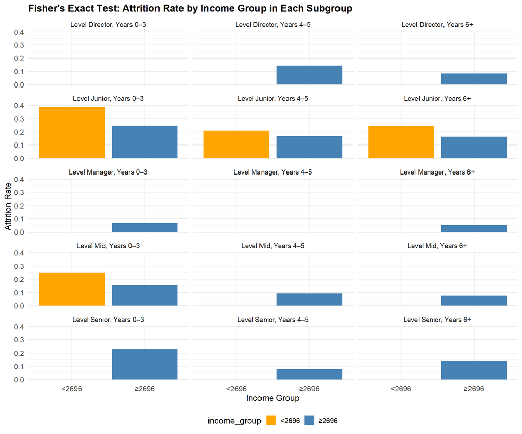

The test results show that only the group of employees at the **JUNIOR LEVEL WITH LESS THAN 3 YEARS OF SERVICE** has a statistically significant association between the minimum salary of 2696 and the attrition rate (p-value = 0.0147), with an odds ratio of approximately 0.5191. This indicates that this salary level may reduce the attrition rate in this group.

Other groups do not show clear statistically significant results (p-value > 0.05 or undefined odds ratio due to insufficient data).

This suggests that the impact of the minimum salary of 2696 on employee retention depends heavily on job level and years of service, being particularly effective for the **JUNIOR LEVEL WITH LESS THAN 3 YEARS OF SERVICE** group.

### 2.1.2. Stock Option Level (Analyzing the Joint Impact of Stock Options and Marital Status on Attrition)

- **H0**: There is no significant difference in the effect of Stock Option Level on Attrition across different Marital Status groups (i.e., the effect of stock options is the same regardless of marital status).
- **H1**: There is a significant difference in the effect of Stock Option Level on Attrition among different Marital Status groups (i.e., an interaction effect exists).**TRUE**

Fisher’s Exact Test: Attrition ~ Stock Option Level by Marital Status

| marital_status | Marital_Status | p_value | odds_ratio | CI | Significant |
| --- | --- | --- | --- | --- | --- |
| Divorced | Divorced | 0.0504 | NA | NA | No |
| Married | **Married** | 0.0014 | NA | NA | **Yes** |
| Single | Single | 1.0000 | NA | NA | No |

The results of Fisher’s Exact Test conducted for each Marital Status group indicate that only the **Married** group shows a statistically significant association between Stock Option Level and Attrition (**p-value = 0.0014**, which is below the significance threshold of 0.05). In contrast, the Divorced and Single groups do not show statistically significant results (p-values = 0.0504 and 1.0000, respectively).

Therefore, there is sufficient evidence to reject the null hypothesis and accept the alternative hypothesis: the effect of stock options on attrition differs across Marital Status groups, with a **particularly significant effect observed in the Married group**. This suggests that being married may increase sensitivity to long-term retention policies such as stock options.

### 2.2. Career Development & Advancement

### 2.2.1. Identifying Promotion-Related Attrition Drivers (Job Level, Promotion, and Role Tenure vs. Attrition)

#### 2.2.1.1. Exploratory Visualization of Promotion-Related Attrition Patterns

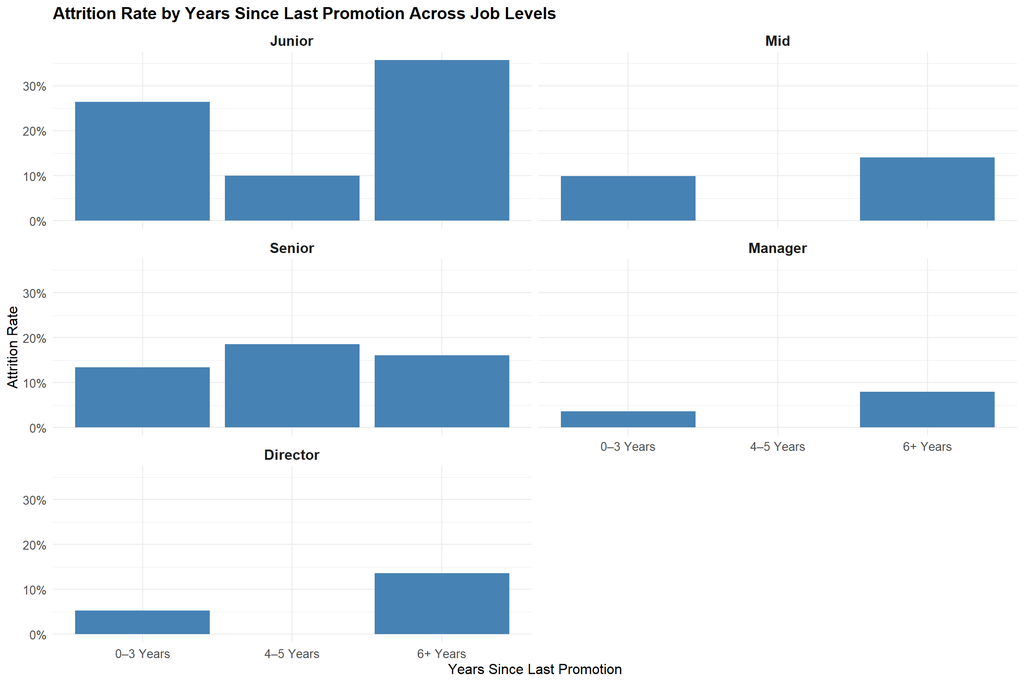

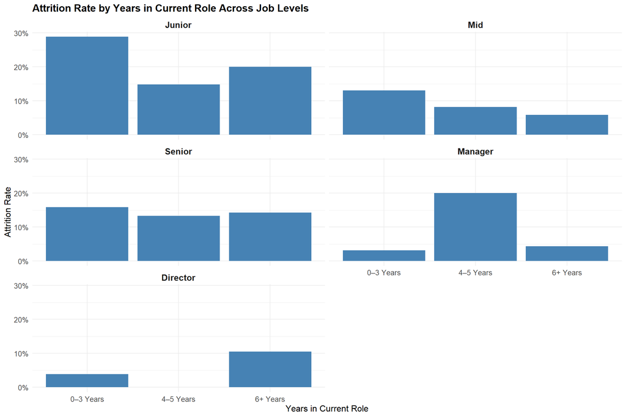

The analysis of attrition rates based on Years Since Last Promotion and Years in Current Role, segmented by Job Level, reveals **non-uniform patterns across different groups**.

In the Junior group — the one with the highest attrition rate — the rate is typically high during the first three years, drops during years 4–5, and then rises again from year 6 onward. In contrast, other job levels do not exhibit a clear increasing or decreasing trend over time.

This suggests that the impact of **promotion wait time** or **tenure in the same role** on attrition decisions **depends heavily on job level**. Therefore, **employee retention policies should be tailored specifically for each job level**, rather than applying a one-size-fits-all solution.

#### 2.2.1.2. Logistic Regression to Quantify the Impact of Promotion Factors on Attrition

```
##
## Call:
## glm(formula = attrition_binary ~ job_level_group * years_since_last_promotion_group +
##     job_level_group * years_in_current_role_group + years_since_last_promotion_group *
##     years_in_current_role_group, family = binomial, data = df_hratt)
##
## Coefficients:
##                                                                     Estimate
## (Intercept)                                                         -0.90039
## job_level_groupOthers                                               -1.10720
## years_since_last_promotion_group4-5                                -14.17676
## years_since_last_promotion_group6+                                   0.96733
## years_in_current_role_group4-5                                      -0.85611
## years_in_current_role_group6+                                       -0.79629
## job_level_groupOthers:years_since_last_promotion_group4-5            0.13453
## job_level_groupOthers:years_since_last_promotion_group6+            -0.24505
## job_level_groupOthers:years_in_current_role_group4-5                 0.58565
## job_level_groupOthers:years_in_current_role_group6+                  0.13839
## years_since_last_promotion_group4-5:years_in_current_role_group4-5  14.21592
## years_since_last_promotion_group6+:years_in_current_role_group4-5   -0.83532
## years_since_last_promotion_group4-5:years_in_current_role_group6+   13.96017
## years_since_last_promotion_group6+:years_in_current_role_group6+     0.01448
##                                                                    Std. Error
## (Intercept)                                                           0.10879
## job_level_groupOthers                                                 0.19311
## years_since_last_promotion_group4-5                                 412.17833
## years_since_last_promotion_group6+                                    0.61516
## years_in_current_role_group4-5                                        0.40747
## years_in_current_role_group6+                                         0.42187
## job_level_groupOthers:years_since_last_promotion_group4-5             0.98629
## job_level_groupOthers:years_since_last_promotion_group6+              0.58069
## job_level_groupOthers:years_in_current_role_group4-5                  0.57284
## job_level_groupOthers:years_in_current_role_group6+                   0.49097
## years_since_last_promotion_group4-5:years_in_current_role_group4-5  412.17973
## years_since_last_promotion_group6+:years_in_current_role_group4-5     1.20360
## years_since_last_promotion_group4-5:years_in_current_role_group6+   412.17866
## years_since_last_promotion_group6+:years_in_current_role_group6+      0.58072
##                                                                    z value
## (Intercept)                                                         -8.276
## job_level_groupOthers                                               -5.733
```

[output cut: 22 more lines]

```
## job_level_groupOthers:years_in_current_role_group6+                  0.7780
## years_since_last_promotion_group4-5:years_in_current_role_group4-5   0.9725
## years_since_last_promotion_group6+:years_in_current_role_group4-5    0.4877
## years_since_last_promotion_group4-5:years_in_current_role_group6+    0.9730
## years_since_last_promotion_group6+:years_in_current_role_group6+     0.9801
## ---
## Signif. codes:  0 '***' 0.001 '**' 0.01 '*' 0.05 '.' 0.1 ' ' 1
##
## (Dispersion parameter for binomial family taken to be 1)
##
##     Null deviance: 1298.6  on 1469  degrees of freedom
## Residual deviance: 1208.9  on 1456  degrees of freedom
## AIC: 1236.9
##
## Number of Fisher Scoring iterations: 14
```

```
##                                                        (Intercept)
##                                                       4.064098e-01
##                                              job_level_groupOthers
##                                                       3.304818e-01
##                                years_since_last_promotion_group4-5
##                                                       6.968021e-07
##                                 years_since_last_promotion_group6+
##                                                       2.630902e+00
##                                     years_in_current_role_group4-5
##                                                       4.248099e-01
##                                      years_in_current_role_group6+
##                                                       4.510001e-01
##          job_level_groupOthers:years_since_last_promotion_group4-5
##                                                       1.143997e+00
##           job_level_groupOthers:years_since_last_promotion_group6+
##                                                       7.826679e-01
##               job_level_groupOthers:years_in_current_role_group4-5
##                                                       1.796157e+00
##                job_level_groupOthers:years_in_current_role_group6+
##                                                       1.148429e+00
## years_since_last_promotion_group4-5:years_in_current_role_group4-5
##                                                       1.492439e+06
##  years_since_last_promotion_group6+:years_in_current_role_group4-5
##                                                       4.337353e-01
##  years_since_last_promotion_group4-5:years_in_current_role_group6+
##                                                       1.155647e+06
##   years_since_last_promotion_group6+:years_in_current_role_group6+
##                                                       1.014588e+00
```

In this step, a logistic regression analysis was conducted to examine the potential interaction effects between three promotion-related variables—**Job Level**, **Years Since Last Promotion**, and **Years in Current Role**—on the likelihood of employee attrition. The objective was to determine whether combinations of these factors help identify high-risk employee groups more clearly, thus enabling more targeted retention strategies.

The results reaffirm that **Job Level** remains the most influential predictor, with a highly significant coefficient estimate of **-1.107 (p < 0.001)**, corresponding to an **odds ratio of approximately 0.33**. This indicates that employees who are not in the Junior group (i.e., classified as “Others”) are only about **33% as likely to leave** as Junior-level employees, reinforcing the conclusion that lower-level staff are at the highest risk of attrition.

In contrast, the effects of **Years Since Last Promotion** and **Years in Current Role** were weaker and statistically less robust. For example, employees who have not been promoted for **6+ years** showed an elevated attrition risk (**odds ratio ≈ 2.63**), but the associated **p-value = 0.1158** suggests this effect is not statistically significant. Similarly, employees who have remained in the same role for **4–6 years** showed reduced likelihood of leaving (**odds ratio < 0.5**), with the **4–5 years group reaching statistical significance (p = 0.0356)**.

Notably, when interaction terms between the three variables were included in the model, none reached statistical significance. Terms such as `years_since_last_promotion_group4-5:years_in_current_role_group6+` or `job_level_groupOthers:years_since_last_promotion_group6+` had **p-values greater than 0.5**, indicating that **individual variable effects dominate**, and combinations of these variables did not yield clearer patterns of risk.

In summary, when quantifying the influence of promotion-related factors on attrition, **Job Level** consistently emerges as the most critical factor. While **Years Since Last Promotion** and **Years in Current Role** provide supplementary insights, their interaction effects do not significantly enhance the predictive power of the model. These findings suggest that **retention programs should prioritize Junior-level employees**, particularly those who **have not been promoted in a long time** or who **have been stagnant in the same role for several years**.

#### 2.2.1.3. Identifying High-Risk Employee Segments for Targeted Retention Strategies

Employee Segments Most Sensitive to Low Income (Monthly Income < 2696)

| Years in Current Role | Years Since Last Promotion | Job Level | Total (Below 2696) | Attrition = Yes (Below 2696) | Attrition Rate (Below 2696) | Total (Above 2696) | Attrition = Yes (Above 2696) | Attrition Rate (Above 2696) | Attrition Rate Gap |
| --- | --- | --- | --- | --- | --- | --- | --- | --- | --- |
| 0–3 years | 0–3 years | Junior | 235 | 80 | 34.0% | 173 | 37 | 21.4% | 12.6% |

The analysis reveals that **junior employees with 0–3 years in their current role and 0–3 years since their last promotion** are the most sensitive to low income. Within this group, those earning **below 2696** exhibit an attrition rate of **34.0%**, compared to **21.4%** among their counterparts earning above that threshold — a notable gap of **12.6 percentage points**.

This suggests that **low salary levels significantly intensify attrition risk** for early-career employees who are still building experience and awaiting advancement. These individuals may perceive **limited financial reward and growth opportunities**, leading to disengagement.

Addressing this issue may require: - **More competitive entry-level compensation** - **Clearer promotion timelines** - **Early developmental support**

These interventions can help retain emerging talent and reduce premature turnover in this critical group.

### 2.2.2. Identifying Training-Related Attrition Drivers (Training Times Last Year, and Overtime vs. Attrition)

- **H0**: There is no relationship or interaction effect between the number of training sessions per year and overtime status on employee attrition.
- **H1**: Employees who work overtime tend to have less time to attend training sessions — i.e., there is a negative association between overtime and training frequency.**FALSE**

```
##
## Call:
## glm(formula = attrition_binary ~ training_times_last_year * over_time,
##     family = binomial, data = df_hratt)
##
## Coefficients:
##                                        Estimate Std. Error z value Pr(>|z|)
## (Intercept)                           -1.884946   0.236191  -7.981 1.46e-15 ***
## training_times_last_year              -0.094592   0.078111  -1.211 0.225895
## over_timeYes                           1.324247   0.352638   3.755 0.000173 ***
## training_times_last_year:over_timeYes -0.005609   0.121135  -0.046 0.963066
## ---
## Signif. codes:  0 '***' 0.001 '**' 0.01 '*' 0.05 '.' 0.1 ' ' 1
##
## (Dispersion parameter for binomial family taken to be 1)
##
##     Null deviance: 1298.6  on 1469  degrees of freedom
## Residual deviance: 1214.5  on 1466  degrees of freedom
## AIC: 1222.5
##
## Number of Fisher Scoring iterations: 4
```

The **overtime variable (over_timeYes)** has a **highly significant impact** on attrition, with an estimated coefficient of **1.324** (p-value = 0.000173). This means that employees who work overtime have a much higher risk of leaving compared to those who do not.

The **number of training sessions in the past year (training_times_last_year)** shows **no clear effect** on attrition (p-value = 0.2259).

Most importantly, the **interaction between training frequency and overtime (training_times_last_year:over_timeYes)** is **not statistically significant** (p-value = 0.963). This indicates there is no evidence that overtime reduces training participation or that their combined effect influences attrition.

Although overtime increases the risk of attrition, the number of training sessions does not have a significant impact, nor does it interact with overtime in affecting attrition. Therefore, retention policies should focus on addressing overtime workload rather than worrying about its effect on training time.

### 2.2. Work-Life Balance & Flexibility

In this step, I examine the relationship between employee attrition and key variables associated with **Work-Life Balance and Flexibility**, including `OverTime_Bin`, `DistanceFromHome`, `BusinessTravel`, and `WorkLifeBalance`. Using a **logistic regression model** in combination with a **forest plot visualization**, this analysis aims to identify which factors have the most significant impact on attrition. The goal is to determine which variables should be prioritized in future **policy interventions** to effectively reduce employee turnover.

```
##
## Call:
## glm(formula = attrition_binary ~ over_time_bin + distance_from_home +
##     business_travel + work_life_balance, family = binomial(),
##     data = df_hratt)
##
## Coefficients:
##                      Estimate Std. Error z value Pr(>|z|)
## (Intercept)         -1.868408   0.155752 -11.996  < 2e-16 ***
## over_time_bin        1.317745   0.154568   8.525  < 2e-16 ***
## distance_from_home   0.021813   0.009172   2.378 0.017394 *
## business_travel.L    0.463996   0.121592   3.816 0.000136 ***
## work_life_balance.L -0.547091   0.240206  -2.278 0.022751 *
## work_life_balance.Q  0.654185   0.199934   3.272 0.001068 **
## work_life_balance.C -0.051106   0.147743  -0.346 0.729411
## ---
## Signif. codes:  0 '***' 0.001 '**' 0.01 '*' 0.05 '.' 0.1 ' ' 1
##
## (Dispersion parameter for binomial family taken to be 1)
##
##     Null deviance: 1205.4  on 1319  degrees of freedom
## Residual deviance: 1098.4  on 1313  degrees of freedom
##   (150 observations deleted due to missingness)
## AIC: 1112.4
##
## Number of Fisher Scoring iterations: 4
```

```
## # A tibble: 6 × 7
##   term                estimate std.error statistic  p.value conf.low conf.high
##   <chr>                  <dbl>     <dbl>     <dbl>    <dbl>    <dbl>     <dbl>
## 1 over_time_bin          3.73    0.155       8.53  1.52e-17    2.76      5.06
## 2 work_life_balance.Q    1.92    0.200       3.27  1.07e- 3    1.29      2.84
## 3 business_travel.L      1.59    0.122       3.82  1.36e- 4    1.25      2.01
## 4 work_life_balance.L    0.579   0.240      -2.28  2.28e- 2    0.361     0.927
## 5 work_life_balance.C    0.950   0.148      -0.346 7.29e- 1    0.709     1.27
## 6 distance_from_home     1.02    0.00917     2.38  1.74e- 2    1.00      1.04
```

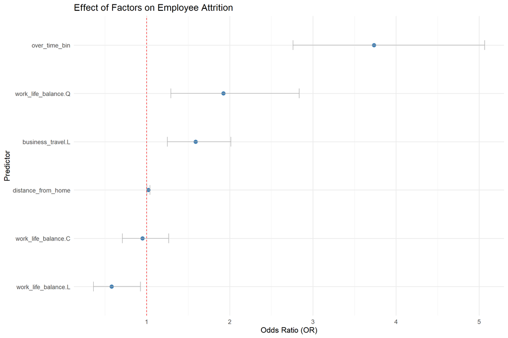

Based on the results of the logistic regression model, the most influential factor affecting employee attrition is **OverTime**. Employees who work overtime are **3.73 times more likely** to leave the company compared to those who do not, and this relationship is **highly statistically significant** (**p < 0.001**).

Next, **Work-Life Balance** also plays a significant role. Specifically, the **quadratic effect** of work-life balance indicates that employees with poorer balance have an approximately **1.92 times higher** risk of attrition (**p ≈ 0.001**). Additionally, the **linear effect** of work-life balance is protective: as employees perceive improvements in work-life balance, their risk of leaving **decreases** (**odds ratio = 0.58**, **p ≈ 0.023**).

The **Business Travel** variable also shows a clear effect: employees who frequently travel for work have about a **1.59 times higher** likelihood of quitting compared to those who travel less or not at all (**p ≈ 0.0001**).

Finally, although the impact of **Distance From Home** is smaller, it is still statistically significant. For every additional kilometer in commuting distance, the risk of attrition increases slightly by about **2%** (**odds ratio = 1.02**, **p ≈ 0.017**).

Summary: Ranking of Impact from Most to Least Significant **OverTime** > **Work-Life Balance** > **Business Travel** > **Distance From Home**

This suggests that managing **overtime**, supporting **work-life balance**, and reviewing **business travel policies** can play an important role in reducing employee turnover.

### 2.3. Employee Engagement & Support

In this step, I conduct a **logistic regression** analysis to explore how the interaction between **Relationship Satisfaction** and **Years Since Last Promotion** (grouped into 0–3 years, 4–5 years, and 6+ years) influences employee attrition. The goal is to uncover actionable insights for designing retention policies tailored to different promotion timelines and satisfaction levels.

```
##
## Call:
## glm(formula = attrition_binary ~ relationship_group * promotion_group,
##     family = binomial, data = df_hratt)
##
## Coefficients:
##                                                Estimate Std. Error z value
## (Intercept)                                    -1.65759    0.08909 -18.605
## relationship_groupLow                           0.34626    0.19012   1.821
## promotion_group4-5 years                       -1.69814    0.59362  -2.861
## promotion_group6+ years                         0.00467    0.22818   0.020
## relationship_groupLow:promotion_group4-5 years  1.83082    0.84114   2.177
## relationship_groupLow:promotion_group6+ years  -0.27746    0.48054  -0.577
##                                                Pr(>|z|)
## (Intercept)                                     < 2e-16 ***
## relationship_groupLow                           0.06857 .
## promotion_group4-5 years                        0.00423 **
## promotion_group6+ years                         0.98367
## relationship_groupLow:promotion_group4-5 years  0.02951 *
## relationship_groupLow:promotion_group6+ years   0.56368
## ---
## Signif. codes:  0 '***' 0.001 '**' 0.01 '*' 0.05 '.' 0.1 ' ' 1
##
## (Dispersion parameter for binomial family taken to be 1)
##
##     Null deviance: 1298.6  on 1469  degrees of freedom
## Residual deviance: 1279.2  on 1464  degrees of freedom
## AIC: 1291.2
##
## Number of Fisher Scoring iterations: 5
```

```
## # A tibble: 6 × 7
##   term                  estimate std.error statistic  p.value conf.low conf.high
##   <chr>                    <dbl>     <dbl>     <dbl>    <dbl>    <dbl>     <dbl>
## 1 (Intercept)              0.191    0.0891  -18.6    2.90e-77   0.159      0.226
## 2 relationship_groupLow    1.41     0.190     1.82   6.86e- 2   0.966      2.04
## 3 promotion_group4-5 y…    0.183    0.594    -2.86   4.23e- 3   0.0445     0.497
## 4 promotion_group6+ ye…    1.00     0.228     0.0205 9.84e- 1   0.631      1.55
## 5 relationship_groupLo…    6.24     0.841     2.18   2.95e- 2   1.20      36.1
## 6 relationship_groupLo…    0.758    0.481    -0.577  5.64e- 1   0.282      1.89
```

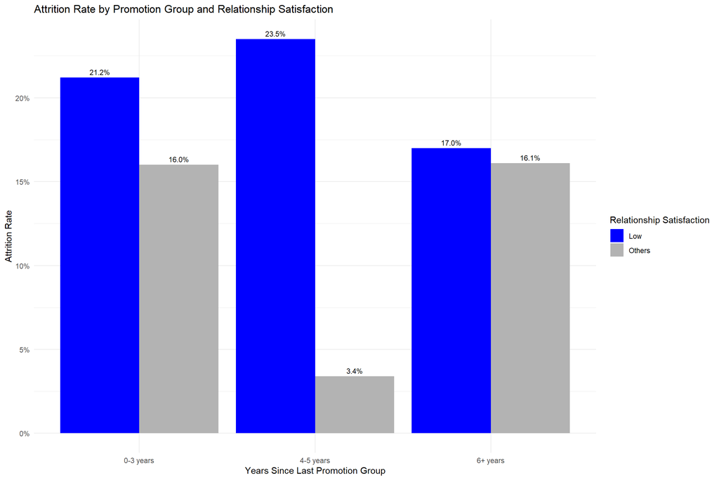

The results from the logistic regression model indicate a **notable interaction** between relationship satisfaction at the workplace and the duration since the last promotion in predicting employee attrition.

Employees in the **“Low” relationship satisfaction** group are more likely to leave the organization compared to other groups.  
This is indicated by a **positive and marginally significant coefficient** with a p-value of **0.06857**.

Employees who have **not been promoted in the past 4–5 years** exhibit a **lower probability of attrition** compared to those who were promoted more recently.  
The coefficient is **negative and statistically significant (p = 0.00423)**.

The **most notable result** lies in the **interaction between the “Low” relationship satisfaction group and the “promotion group = 4–5 years”**:  
The interaction term has a **positive and statistically significant coefficient** (p = **0.02951**), indicating that when **both factors** are present—low relationship satisfaction and a lack of promotion in the past 4–5 years—the **risk of attrition increases significantly**.

In contrast, the interaction between **“relationship satisfaction = Low”** and **“promotion group = 6+ years”** is **not statistically significant** (p = **0.56368**), implying **no meaningful increase** in attrition risk for this group compared to the reference category.

These findings suggest that **dissatisfaction in workplace relationships becomes a pronounced risk factor for attrition**, especially when **combined with a perceived stagnation in career advancement during the 4–5 year window**. This period may represent a **critical psychological threshold** where employee expectations are unmet, potentially leading to decreased motivation or decisions to leave the organization.

### 2.4. Recruitment & Onboarding

### 2.4.1. Profiling High-Risk Hires Based on Career History and Job Level

In this step, I perform a logistic regression analysis to examine the relationship between **Number of Companies Worked**, **Total Working Years**, **Job Level**, and **Attrition**. The goal is to identify whether certain combinations of career history and job seniority are associated with higher attrition risk. By exploring interaction effects among these variables, I aim to pinpoint the most at-risk employee profiles, providing insights to inform more targeted recruitment and onboarding strategies.

Significant Interactions Influencing Attrition

| Term | Estimate | Std. Error | z value | p-value |
| --- | --- | --- | --- | --- |
| (Intercept) | -1.231249 | 0.3850735 | -3.197438 | 0.0013865 |
| num_companies_group5+ | 1.336361 | 0.5993873 | 2.229545 | 0.0257776 |

High Attrition Rate Groups with Practical Significance

| Num Companies | Working Years | Job Level | Total | Attrition = Yes | Attrition Rate |
| --- | --- | --- | --- | --- | --- |
| 1 | 0-5 | Junior | 181 | 60 | 0.331 |

From a practical standpoint, the group with the highest attrition rate consisted of employees who had only worked at **1 company**, had **0–5 years** of total experience, and were in **junior-level** positions. Among 181 individuals in this category, 60 had left the organization, resulting in an attrition rate of 33.1%—significantly higher than the average. This suggests that less experienced employees who have limited exposure to different work environments and are early in their careers may struggle more with organizational fit or adapting to new roles, despite appearing stable based on their limited job history.

### 2.4.2. Evaluating Early Tenure Risk Factors in Relation to Manager Fit and Career Stage

In this step, I investigate the interaction between **Years at Company**, **Job Level**, and **Years with Current Manager** in relation to Attrition using **logistic regression**. This analysis aims to identify which employee groups—based on their tenure with the company and manager, as well as their job seniority—are most likely to leave. I also assess the statistical significance of these patterns to ensure that the insights are reliable for guiding retention-focused onboarding strategies.

Significant Interaction Effects on Attrition

| Term | Estimate | Std. Error | z value | p-value |
| --- | --- | --- | --- | --- |
| years_with_curr_manager_group2+ | -0.9434279 | 0.2662842 | -3.542937 | 0.0003957 |
| job_levelMid | -1.2543668 | 0.3839973 | -3.266603 | 0.0010885 |

High-Attrition Employee Groups

| Years at Company | Job Level | Years with Manager | Total | Attrition = Yes | Attrition Rate |
| --- | --- | --- | --- | --- | --- |
| 0-3 | Junior | 0-1 | 154 | 65 | 0.422 |
| 4+ | Junior | 2+ | 230 | 42 | 0.183 |

The analysis revealed several statistically significant effects. Employees who had **worked with their current manager for 2 or more years** were significantly **less likely to leave** (Estimate = -0.94, p < 0.001), emphasizing the value of stable manager-employee relationships in reducing attrition. Similarly, **mid-level** employees showed a much **lower likelihood of leaving** compared to junior staff (Estimate = -1.25, p < 0.01), suggesting that greater job experience and organizational embeddedness can act as retention buffers.

From a practical standpoint, the most vulnerable group comprised employees with **0–3 years at the company**, in **junior-level** positions, and with only **0–1 year under their current manager**. Among 154 individuals in this category, 65 had left, resulting in a 42.2% attrition rate—the highest observed. In contrast, **junior** employees with **4+ years at the company** and **2+ years with their manager** had a much **lower attrition rate** of 18.3%, highlighting how both organizational and managerial tenure help foster stability.

These findings underscore the importance of early relationship-building between junior employees and their managers. Investing in consistent leadership support during the first years of employment may significantly reduce turnover risk in this vulnerable group.